# costs

```python
import pandas as pd
import numpy as np
from os import listdir
from os.path import isfile, join
import matplotlib.pyplot as plt
import datetime
from datetime import timedelta
from functools import reduce
import warnings
```

```python
!pwd
```

```
/Users/shashank/Desktop/BIDS/datahub_usage/grafana-analysis/notebooks
```

This is a Jan 21 costs data.

```python
jan21 = pd.read_csv("../data/GCP/21-01.csv", skiprows = 7)
jan21
```

|  | Billing account name | Billing account ID | Project name | Project ID | Service description | Service ID | SKU description | SKU ID | Credit type | Cost type | Usage start date | Usage end date | Usage amount | Usage unit | Unrounded Cost ($) | Cost ($) | Unnamed: 16 |
| --- | --- | --- | --- | --- | --- | --- | --- | --- | --- | --- | --- | --- | --- | --- | --- | --- | --- |
| 0 | Data Hub | 01A56A-FF37DD-411346 | ucb-datahub-2018 | ucb-datahub-2018 | Compute Engine | 6F81-5844-456A | Balanced PD Capacity | 6AE1-525F-8B80 | NaN | Usage | 2021-01-01 | 2021-01-31 | 22,732.651 | gibibyte month | 2273.264728 | 2273.26 | NaN |
| 1 | Data Hub | 01A56A-FF37DD-411346 | ucb-datahub-2018 | ucb-datahub-2018 | Compute Engine | 6F81-5844-456A | N1 Predefined Instance Core running in Americas | 2E27-4F75-95CD | NaN | Usage | 2021-01-01 | 2021-01-31 | 44,232.23 | hour | 1398.224622 | 1398.22 | NaN |
| 2 | Data Hub | 01A56A-FF37DD-411346 | ucb-datahub-2018 | ucb-datahub-2018 | Compute Engine | 6F81-5844-456A | N1 Predefined Instance Core running in Americas | 2E27-4F75-95CD | NaN | Usage | 2021-01-08 | 2021-01-31 | 38,637.833 | hour | 1221.380316 | 1221.38 | NaN |
| 3 | Data Hub | 01A56A-FF37DD-411346 | ucb-datahub-2018 | ucb-datahub-2018 | Compute Engine | 6F81-5844-456A | N1 Predefined Instance Ram running in Americas | 6C71-E844-38BC | NaN | Usage | 2021-01-01 | 2021-01-31 | 286,551.741 | gibibyte hour | 1214.119313 | 1214.12 | NaN |
| 4 | Data Hub | 01A56A-FF37DD-411346 | ucb-datahub-2018 | ucb-datahub-2018 | Compute Engine | 6F81-5844-456A | N1 Predefined Instance Ram running in Americas | 6C71-E844-38BC | NaN | Usage | 2021-01-08 | 2021-01-31 | 243,919.773 | gibibyte hour | 1033.487876 | 1033.49 | NaN |
| ... | ... | ... | ... | ... | ... | ... | ... | ... | ... | ... | ... | ... | ... | ... | ... | ... | ... |
| 134 | Data Hub | 01A56A-FF37DD-411346 | ucb-datahub-2018 | ucb-datahub-2018 | Compute Engine | 6F81-5844-456A | N1 Predefined Instance Ram running in Americas | 6C71-E844-38BC | SUSTAINED_USAGE_DISCOUNT | Usage | 2021-01-08 | 2021-01-31 | NaN | NaN | -494.847179 | -494.85 | NaN |
| 135 | Data Hub | 01A56A-FF37DD-411346 | ucb-datahub-2018 | ucb-datahub-2018 | Compute Engine | 6F81-5844-456A | N1 Predefined Instance Core running in Americas | 2E27-4F75-95CD | SUSTAINED_USAGE_DISCOUNT | Usage | 2021-01-08 | 2021-01-31 | NaN | NaN | -579.926026 | -579.93 | NaN |
| 136 | NaN | NaN | NaN | NaN | NaN | NaN | NaN | NaN | NaN | Rounding error | NaN | NaN | NaN | NaN | -0.016631 | NaN | NaN |
| 137 | NaN | NaN | NaN | NaN | NaN | NaN | NaN | NaN | NaN | Rounding error | NaN | NaN | NaN | NaN | 0.000000 | NaN | NaN |
| 138 | NaN | NaN | NaN | NaN | NaN | NaN | NaN | NaN | NaN | Total | NaN | NaN | NaN | NaN | 9776.200000 | 9776.20 | NaN |

139 rows × 17 columns

First filter for overall datahub expenses. (the rest is for Data8X on EdX)

```python
jan21_datahub = jan21[jan21["Project name"] == "ucb-datahub-2018"]
jan21_datahub
```

|  | Billing account name | Billing account ID | Project name | Project ID | Service description | Service ID | SKU description | SKU ID | Credit type | Cost type | Usage start date | Usage end date | Usage amount | Usage unit | Unrounded Cost ($) | Cost ($) | Unnamed: 16 |
| --- | --- | --- | --- | --- | --- | --- | --- | --- | --- | --- | --- | --- | --- | --- | --- | --- | --- |
| 0 | Data Hub | 01A56A-FF37DD-411346 | ucb-datahub-2018 | ucb-datahub-2018 | Compute Engine | 6F81-5844-456A | Balanced PD Capacity | 6AE1-525F-8B80 | NaN | Usage | 2021-01-01 | 2021-01-31 | 22,732.651 | gibibyte month | 2273.264728 | 2273.26 | NaN |
| 1 | Data Hub | 01A56A-FF37DD-411346 | ucb-datahub-2018 | ucb-datahub-2018 | Compute Engine | 6F81-5844-456A | N1 Predefined Instance Core running in Americas | 2E27-4F75-95CD | NaN | Usage | 2021-01-01 | 2021-01-31 | 44,232.23 | hour | 1398.224622 | 1398.22 | NaN |
| 2 | Data Hub | 01A56A-FF37DD-411346 | ucb-datahub-2018 | ucb-datahub-2018 | Compute Engine | 6F81-5844-456A | N1 Predefined Instance Core running in Americas | 2E27-4F75-95CD | NaN | Usage | 2021-01-08 | 2021-01-31 | 38,637.833 | hour | 1221.380316 | 1221.38 | NaN |
| 3 | Data Hub | 01A56A-FF37DD-411346 | ucb-datahub-2018 | ucb-datahub-2018 | Compute Engine | 6F81-5844-456A | N1 Predefined Instance Ram running in Americas | 6C71-E844-38BC | NaN | Usage | 2021-01-01 | 2021-01-31 | 286,551.741 | gibibyte hour | 1214.119313 | 1214.12 | NaN |
| 4 | Data Hub | 01A56A-FF37DD-411346 | ucb-datahub-2018 | ucb-datahub-2018 | Compute Engine | 6F81-5844-456A | N1 Predefined Instance Ram running in Americas | 6C71-E844-38BC | NaN | Usage | 2021-01-08 | 2021-01-31 | 243,919.773 | gibibyte hour | 1033.487876 | 1033.49 | NaN |
| ... | ... | ... | ... | ... | ... | ... | ... | ... | ... | ... | ... | ... | ... | ... | ... | ... | ... |
| 128 | Data Hub | 01A56A-FF37DD-411346 | ucb-datahub-2018 | ucb-datahub-2018 | Compute Engine | 6F81-5844-456A | Network Inter Zone Ingress | D0CC-50DF-59D2 | NaN | Usage | 2021-01-01 | 2021-01-31 | 1,844.249 | gibibyte | 0.000000 | 0.00 | NaN |
| 132 | Data Hub | 01A56A-FF37DD-411346 | ucb-datahub-2018 | ucb-datahub-2018 | Compute Engine | 6F81-5844-456A | E2 Instance Ram running in Americas | F449-33EC-A5EF | COMMITTED_USAGE_DISCOUNT | Usage | 2021-01-01 | 2021-01-31 | NaN | NaN | -209.408635 | -209.41 | NaN |
| 133 | Data Hub | 01A56A-FF37DD-411346 | ucb-datahub-2018 | ucb-datahub-2018 | Compute Engine | 6F81-5844-456A | E2 Instance Core running in Americas | CF4E-A0C7-E3BF | COMMITTED_USAGE_DISCOUNT | Usage | 2021-01-01 | 2021-01-31 | NaN | NaN | -259.645377 | -259.65 | NaN |
| 134 | Data Hub | 01A56A-FF37DD-411346 | ucb-datahub-2018 | ucb-datahub-2018 | Compute Engine | 6F81-5844-456A | N1 Predefined Instance Ram running in Americas | 6C71-E844-38BC | SUSTAINED_USAGE_DISCOUNT | Usage | 2021-01-08 | 2021-01-31 | NaN | NaN | -494.847179 | -494.85 | NaN |
| 135 | Data Hub | 01A56A-FF37DD-411346 | ucb-datahub-2018 | ucb-datahub-2018 | Compute Engine | 6F81-5844-456A | N1 Predefined Instance Core running in Americas | 2E27-4F75-95CD | SUSTAINED_USAGE_DISCOUNT | Usage | 2021-01-08 | 2021-01-31 | NaN | NaN | -579.926026 | -579.93 | NaN |

73 rows × 17 columns

```python
jan21_datahub["Usage unit"].value_counts()
```

```
gibibyte               41
hour                   13
gibibyte hour           6
gibibyte month          6
count                   2
active key versions     1
Name: Usage unit, dtype: int64
```

The grafana data is of 3 types: Memeory usage, CPU and active users. It is also divided by hubs. I will try to show what protioion of costs are attributed to which hub on a given day.

First we have to split up costs in 3 categories. I will show the split on Jan 21 as a sample.

### Instance Costs for CPU (usage unit hour)

```python
#jan21_datahub[jan21_datahub["Usage unit"] == "hour"]
```

We looks at all instance costs not attributed to RAM. The usage unit is 'hour'. Note that there are other rows with usage unit hour, but with small costs and a different 'SKU description'. We get discounts as well.

```python
jan21_datahub[(jan21_datahub["SKU description"].str.contains(r"(N1)|(E2)")) &
             ~(jan21_datahub["SKU description"].str.contains("Ram"))]
```

|  | Billing account name | Billing account ID | Project name | Project ID | Service description | Service ID | SKU description | SKU ID | Credit type | Cost type | Usage start date | Usage end date | Usage amount | Usage unit | Unrounded Cost ($) | Cost ($) | Unnamed: 16 |
| --- | --- | --- | --- | --- | --- | --- | --- | --- | --- | --- | --- | --- | --- | --- | --- | --- | --- |
| 1 | Data Hub | 01A56A-FF37DD-411346 | ucb-datahub-2018 | ucb-datahub-2018 | Compute Engine | 6F81-5844-456A | N1 Predefined Instance Core running in Americas | 2E27-4F75-95CD | NaN | Usage | 2021-01-01 | 2021-01-31 | 44,232.23 | hour | 1398.224622 | 1398.22 | NaN |
| 2 | Data Hub | 01A56A-FF37DD-411346 | ucb-datahub-2018 | ucb-datahub-2018 | Compute Engine | 6F81-5844-456A | N1 Predefined Instance Core running in Americas | 2E27-4F75-95CD | NaN | Usage | 2021-01-08 | 2021-01-31 | 38,637.833 | hour | 1221.380316 | 1221.38 | NaN |
| 10 | Data Hub | 01A56A-FF37DD-411346 | ucb-datahub-2018 | ucb-datahub-2018 | Compute Engine | 6F81-5844-456A | E2 Instance Core running in Americas | CF4E-A0C7-E3BF | NaN | Usage | 2021-01-01 | 2021-01-31 | 13,950.624 | hour | 304.285043 | 304.29 | NaN |
| 14 | Data Hub | 01A56A-FF37DD-411346 | ucb-datahub-2018 | ucb-datahub-2018 | Compute Engine | 6F81-5844-456A | Commitment v1: E2 Cpu in Americas for 1 Year | F0E3-4F53-A0FB | NaN | Usage | 2021-01-01 | 2021-01-31 | 11,904 | hour | 163.576304 | 163.58 | NaN |
| 19 | Data Hub | 01A56A-FF37DD-411346 | ucb-datahub-2018 | ucb-datahub-2018 | Compute Engine | 6F81-5844-456A | E2 Instance Core running in Americas | CF4E-A0C7-E3BF | NaN | Usage | 2021-01-01 | 2021-01-31 | 3,956.523 | hour | 86.297986 | 86.30 | NaN |
| 133 | Data Hub | 01A56A-FF37DD-411346 | ucb-datahub-2018 | ucb-datahub-2018 | Compute Engine | 6F81-5844-456A | E2 Instance Core running in Americas | CF4E-A0C7-E3BF | COMMITTED_USAGE_DISCOUNT | Usage | 2021-01-01 | 2021-01-31 | NaN | NaN | -259.645377 | -259.65 | NaN |
| 135 | Data Hub | 01A56A-FF37DD-411346 | ucb-datahub-2018 | ucb-datahub-2018 | Compute Engine | 6F81-5844-456A | N1 Predefined Instance Core running in Americas | 2E27-4F75-95CD | SUSTAINED_USAGE_DISCOUNT | Usage | 2021-01-08 | 2021-01-31 | NaN | NaN | -579.926026 | -579.93 | NaN |

### RAM costs are to be used along with memory usage from grafana

```python
#jan21_datahub[jan21_datahub["Usage unit"] == "gibibyte hour"]
```

Note that usage unit is gibibyte hour. We get discounts as well.

```python
jan21_datahub[jan21_datahub["SKU description"].str.contains("Ram")]
```

|  | Billing account name | Billing account ID | Project name | Project ID | Service description | Service ID | SKU description | SKU ID | Credit type | Cost type | Usage start date | Usage end date | Usage amount | Usage unit | Unrounded Cost ($) | Cost ($) | Unnamed: 16 |
| --- | --- | --- | --- | --- | --- | --- | --- | --- | --- | --- | --- | --- | --- | --- | --- | --- | --- |
| 3 | Data Hub | 01A56A-FF37DD-411346 | ucb-datahub-2018 | ucb-datahub-2018 | Compute Engine | 6F81-5844-456A | N1 Predefined Instance Ram running in Americas | 6C71-E844-38BC | NaN | Usage | 2021-01-01 | 2021-01-31 | 286,551.741 | gibibyte hour | 1214.119313 | 1214.12 | NaN |
| 4 | Data Hub | 01A56A-FF37DD-411346 | ucb-datahub-2018 | ucb-datahub-2018 | Compute Engine | 6F81-5844-456A | N1 Predefined Instance Ram running in Americas | 6C71-E844-38BC | NaN | Usage | 2021-01-08 | 2021-01-31 | 243,919.773 | gibibyte hour | 1033.487876 | 1033.49 | NaN |
| 11 | Data Hub | 01A56A-FF37DD-411346 | ucb-datahub-2018 | ucb-datahub-2018 | Compute Engine | 6F81-5844-456A | E2 Instance Ram running in Americas | F449-33EC-A5EF | NaN | Usage | 2021-01-01 | 2021-01-31 | 60,900.828 | gibibyte hour | 178.045138 | 178.05 | NaN |
| 13 | Data Hub | 01A56A-FF37DD-411346 | ucb-datahub-2018 | ucb-datahub-2018 | Compute Engine | 6F81-5844-456A | Commitment v1: E2 Ram in Americas for 1 Year | 8826-F8CF-0346 | NaN | Usage | 2021-01-01 | 2021-01-31 | 95,232 | gibibyte hour | 175.400416 | 175.40 | NaN |
| 26 | Data Hub | 01A56A-FF37DD-411346 | ucb-datahub-2018 | ucb-datahub-2018 | Compute Engine | 6F81-5844-456A | E2 Instance Ram running in Americas | F449-33EC-A5EF | NaN | Usage | 2021-01-01 | 2021-01-30 | 10,727.764 | gibibyte hour | 31.362889 | 31.36 | NaN |
| 132 | Data Hub | 01A56A-FF37DD-411346 | ucb-datahub-2018 | ucb-datahub-2018 | Compute Engine | 6F81-5844-456A | E2 Instance Ram running in Americas | F449-33EC-A5EF | COMMITTED_USAGE_DISCOUNT | Usage | 2021-01-01 | 2021-01-31 | NaN | NaN | -209.408635 | -209.41 | NaN |
| 134 | Data Hub | 01A56A-FF37DD-411346 | ucb-datahub-2018 | ucb-datahub-2018 | Compute Engine | 6F81-5844-456A | N1 Predefined Instance Ram running in Americas | 6C71-E844-38BC | SUSTAINED_USAGE_DISCOUNT | Usage | 2021-01-08 | 2021-01-31 | NaN | NaN | -494.847179 | -494.85 | NaN |

### Storage costs with the usage unit gibibyte month

Storage costs are significant. They are 40% for Jan 21.

```python
jan21_datahub[jan21_datahub["Usage unit"] == "gibibyte month"]
```

|  | Billing account name | Billing account ID | Project name | Project ID | Service description | Service ID | SKU description | SKU ID | Credit type | Cost type | Usage start date | Usage end date | Usage amount | Usage unit | Unrounded Cost ($) | Cost ($) | Unnamed: 16 |
| --- | --- | --- | --- | --- | --- | --- | --- | --- | --- | --- | --- | --- | --- | --- | --- | --- | --- |
| 0 | Data Hub | 01A56A-FF37DD-411346 | ucb-datahub-2018 | ucb-datahub-2018 | Compute Engine | 6F81-5844-456A | Balanced PD Capacity | 6AE1-525F-8B80 | NaN | Usage | 2021-01-01 | 2021-01-31 | 22,732.651 | gibibyte month | 2273.264728 | 2273.26 | NaN |
| 5 | Data Hub | 01A56A-FF37DD-411346 | ucb-datahub-2018 | ucb-datahub-2018 | Compute Engine | 6F81-5844-456A | SSD backed PD Capacity | B188-61DD-52E4 | NaN | Usage | 2021-01-01 | 2021-01-31 | 3,685.205 | gibibyte month | 626.484423 | 626.48 | NaN |
| 6 | Data Hub | 01A56A-FF37DD-411346 | ucb-datahub-2018 | ucb-datahub-2018 | Compute Engine | 6F81-5844-456A | Storage Machine Image | A652-E97D-AB77 | NaN | Usage | 2021-01-01 | 2021-01-31 | 8,902.764 | gibibyte month | 445.138029 | 445.14 | NaN |
| 7 | Data Hub | 01A56A-FF37DD-411346 | ucb-datahub-2018 | ucb-datahub-2018 | Compute Engine | 6F81-5844-456A | Storage PD Capacity | D973-5D65-BAB2 | NaN | Usage | 2021-01-01 | 2021-01-31 | 10,384.891 | gibibyte month | 414.850057 | 414.85 | NaN |
| 9 | Data Hub | 01A56A-FF37DD-411346 | ucb-datahub-2018 | ucb-datahub-2018 | Compute Engine | 6F81-5844-456A | Storage PD Snapshot in US | 34CF-7D88-5D40 | NaN | Usage | 2021-01-01 | 2021-01-31 | 12,106.928 | gibibyte month | 314.779513 | 314.78 | NaN |
| 28 | Data Hub | 01A56A-FF37DD-411346 | ucb-datahub-2018 | ucb-datahub-2018 | Cloud Storage | 95FF-2EF5-5EA1 | Standard Storage US Multi-region | 0D5D-6E23-4250 | NaN | Usage | 2021-01-01 | 2021-01-31 | 771.23 | gibibyte month | 20.051943 | 20.05 | NaN |

### Unsure

I am unsure where to classify these costs. Note their amounts are very small.

```python
jan21_datahub[jan21_datahub["Usage unit"] == "gibibyte"]
```

|  | Billing account name | Billing account ID | Project name | Project ID | Service description | Service ID | SKU description | SKU ID | Credit type | Cost type | Usage start date | Usage end date | Usage amount | Usage unit | Unrounded Cost ($) | Cost ($) | Unnamed: 16 |
| --- | --- | --- | --- | --- | --- | --- | --- | --- | --- | --- | --- | --- | --- | --- | --- | --- | --- |
| 23 | Data Hub | 01A56A-FF37DD-411346 | ucb-datahub-2018 | ucb-datahub-2018 | Compute Engine | 6F81-5844-456A | Network Internet Egress from Americas to Americas | F274-1692-F213 | NaN | Usage | 2021-01-01 | 2021-01-31 | 455.451 | gibibyte | 54.563291 | 54.56 | NaN |
| 36 | Data Hub | 01A56A-FF37DD-411346 | ucb-datahub-2018 | ucb-datahub-2018 | Stackdriver Logging | 5490-F7B7-8DF6 | Log Volume | 143F-A1B0-E0BE | NaN | Usage | 2021-01-01 | 2021-01-31 | 66.735 | gibibyte | 8.366828 | 8.37 | NaN |
| 38 | Data Hub | 01A56A-FF37DD-411346 | ucb-datahub-2018 | ucb-datahub-2018 | Compute Engine | 6F81-5844-456A | Network Load Balancing: Data Processing Charge... | EECF-0EFC-74CA | NaN | Usage | 2021-01-01 | 2021-01-31 | 628.413 | gibibyte | 5.026867 | 5.03 | NaN |
| 39 | Data Hub | 01A56A-FF37DD-411346 | ucb-datahub-2018 | ucb-datahub-2018 | Compute Engine | 6F81-5844-456A | Network Inter Zone Egress | DE9E-AFBC-A15A | NaN | Usage | 2021-01-01 | 2021-01-31 | 429.626 | gibibyte | 4.295827 | 4.30 | NaN |
| 40 | Data Hub | 01A56A-FF37DD-411346 | ucb-datahub-2018 | ucb-datahub-2018 | Compute Engine | 6F81-5844-456A | Network Internet Egress from Americas to APAC | 6B8F-E63D-832B | NaN | Usage | 2021-01-01 | 2021-01-31 | 28.278 | gibibyte | 3.335865 | 3.34 | NaN |
| 41 | Data Hub | 01A56A-FF37DD-411346 | ucb-datahub-2018 | ucb-datahub-2018 | Cloud Storage | 95FF-2EF5-5EA1 | Download Worldwide Destinations (excluding Asi... | 22EB-AAE8-FBCD | NaN | Usage | 2021-01-04 | 2021-01-28 | 26.503 | gibibyte | 3.060320 | 3.06 | NaN |
| 42 | Data Hub | 01A56A-FF37DD-411346 | ucb-datahub-2018 | ucb-datahub-2018 | Compute Engine | 6F81-5844-456A | Network Internet Egress from Americas to China | 9DE9-9092-B3BC | NaN | Usage | 2021-01-01 | 2021-01-31 | 8.9 | gibibyte | 2.046634 | 2.05 | NaN |
| 46 | Data Hub | 01A56A-FF37DD-411346 | ucb-datahub-2018 | ucb-datahub-2018 | Compute Engine | 6F81-5844-456A | Network Internet Egress from Americas to EMEA | DFA5-B5C6-36D6 | NaN | Usage | 2021-01-01 | 2021-01-31 | 7.105 | gibibyte | 0.835681 | 0.84 | NaN |
| 49 | Data Hub | 01A56A-FF37DD-411346 | ucb-datahub-2018 | ucb-datahub-2018 | Compute Engine | 6F81-5844-456A | Network Internet Egress from Americas to Austr... | FDBC-6E3B-D4D8 | NaN | Usage | 2021-01-01 | 2021-01-31 | 1.636 | gibibyte | 0.310131 | 0.31 | NaN |
| 59 | Data Hub | 01A56A-FF37DD-411346 | ucb-datahub-2018 | ucb-datahub-2018 | Compute Engine | 6F81-5844-456A | Network Egress via Carrier Peering Network - A... | 984A-1F27-2D1F | NaN | Usage | 2021-01-01 | 2021-01-31 | 0.042 | gibibyte | 0.001337 | 0.00 | NaN |
| 60 | Data Hub | 01A56A-FF37DD-411346 | ucb-datahub-2018 | ucb-datahub-2018 | Compute Engine | 6F81-5844-456A | Network Inter Region Egress from Americas to V... | C863-37DA-506E | NaN | Usage | 2021-01-01 | 2021-01-31 | 0.124 | gibibyte | 0.001226 | 0.00 | NaN |
| 63 | Data Hub | 01A56A-FF37DD-411346 | ucb-datahub-2018 | ucb-datahub-2018 | Compute Engine | 6F81-5844-456A | Network Inter Region Egress from Americas to L... | 0C3C-6B13-B1E8 | NaN | Usage | 2021-01-05 | 2021-01-29 | 0.029 | gibibyte | 0.000276 | 0.00 | NaN |
| 67 | Data Hub | 01A56A-FF37DD-411346 | ucb-datahub-2018 | ucb-datahub-2018 | Compute Engine | 6F81-5844-456A | Network Inter Region Egress from Americas to S... | E600-FADE-52E5 | NaN | Usage | 2021-01-06 | 2021-01-31 | 0 | gibibyte | 0.000010 | 0.00 | NaN |
| 68 | Data Hub | 01A56A-FF37DD-411346 | ucb-datahub-2018 | ucb-datahub-2018 | Compute Engine | 6F81-5844-456A | Network Inter Region Egress from Americas to S... | 40D6-DDD1-E008 | NaN | Usage | 2021-01-15 | 2021-01-15 | 0.001 | gibibyte | 0.000008 | 0.00 | NaN |
| 69 | Data Hub | 01A56A-FF37DD-411346 | ucb-datahub-2018 | ucb-datahub-2018 | Compute Engine | 6F81-5844-456A | Network Inter Region Egress from Americas to L... | ACC0-9F23-6029 | NaN | Usage | 2021-01-14 | 2021-01-30 | 0 | gibibyte | 0.000003 | 0.00 | NaN |
| 76 | Data Hub | 01A56A-FF37DD-411346 | ucb-datahub-2018 | ucb-datahub-2018 | Compute Engine | 6F81-5844-456A | Network Inter Region Egress from Americas to J... | DE89-F11A-D163 | NaN | Usage | 2021-01-01 | 2021-01-29 | 0.001 | gibibyte | 0.000000 | 0.00 | NaN |
| 85 | Data Hub | 01A56A-FF37DD-411346 | ucb-datahub-2018 | ucb-datahub-2018 | Compute Engine | 6F81-5844-456A | Network Internet Ingress from Australia to Ame... | 773D-F52D-63CD | NaN | Usage | 2021-01-01 | 2021-01-31 | 154.948 | gibibyte | 0.000000 | 0.00 | NaN |
| 86 | Data Hub | 01A56A-FF37DD-411346 | ucb-datahub-2018 | ucb-datahub-2018 | Compute Engine | 6F81-5844-456A | Network Inter Region Egress from Americas to H... | 7EDC-324D-8320 | NaN | Usage | 2021-01-01 | 2021-01-31 | 0.002 | gibibyte | 0.000000 | 0.00 | NaN |
| 87 | Data Hub | 01A56A-FF37DD-411346 | ucb-datahub-2018 | ucb-datahub-2018 | Compute Engine | 6F81-5844-456A | Network Inter Region Ingress from Japan to Ame... | 8497-0F70-3439 | NaN | Usage | 2021-01-01 | 2021-01-31 | 0.001 | gibibyte | 0.000000 | 0.00 | NaN |
| 88 | Data Hub | 01A56A-FF37DD-411346 | ucb-datahub-2018 | ucb-datahub-2018 | Compute Engine | 6F81-5844-456A | Network Inter Region Ingress from Virginia to ... | 587F-0E36-6A26 | NaN | Usage | 2021-01-01 | 2021-01-31 | 0.018 | gibibyte | 0.000000 | 0.00 | NaN |
| 89 | Data Hub | 01A56A-FF37DD-411346 | ucb-datahub-2018 | ucb-datahub-2018 | Compute Engine | 6F81-5844-456A | Network Google Egress from Americas to Americas | 92CB-C25F-B1D1 | NaN | Usage | 2021-01-01 | 2021-01-31 | 443.2 | gibibyte | 0.000000 | 0.00 | NaN |
| 90 | Data Hub | 01A56A-FF37DD-411346 | ucb-datahub-2018 | ucb-datahub-2018 | Compute Engine | 6F81-5844-456A | Network Ingress via Carrier Peering Network - ... | 427E-B4F2-B5CF | NaN | Usage | 2021-01-01 | 2021-01-31 | 9.038 | gibibyte | 0.000000 | 0.00 | NaN |
| 91 | Data Hub | 01A56A-FF37DD-411346 | ucb-datahub-2018 | ucb-datahub-2018 | Compute Engine | 6F81-5844-456A | Network Intra Zone Ingress | 9C76-A3FB-C60A | NaN | Usage | 2021-01-01 | 2021-01-31 | 7,343.078 | gibibyte | 0.000000 | 0.00 | NaN |
| 93 | Data Hub | 01A56A-FF37DD-411346 | ucb-datahub-2018 | ucb-datahub-2018 | Compute Engine | 6F81-5844-456A | Network Internet Ingress from EMEA to Americas | 2F99-3A90-373B | NaN | Usage | 2021-01-01 | 2021-01-31 | 13.676 | gibibyte | 0.000000 | 0.00 | NaN |
| 95 | Data Hub | 01A56A-FF37DD-411346 | ucb-datahub-2018 | ucb-datahub-2018 | Compute Engine | 6F81-5844-456A | Network Inter Region Egress from Americas to APAC | 2583-7659-D94A | NaN | Usage | 2021-01-01 | 2021-01-31 | 0.203 | gibibyte | 0.000000 | 0.00 | NaN |
| 96 | Data Hub | 01A56A-FF37DD-411346 | ucb-datahub-2018 | ucb-datahub-2018 | Compute Engine | 6F81-5844-456A | Network Inter Region Ingress from APAC to Amer... | BBF8-C07D-1DF4 | NaN | Usage | 2021-01-01 | 2021-01-31 | 0.206 | gibibyte | 0.000000 | 0.00 | NaN |
| 97 | Data Hub | 01A56A-FF37DD-411346 | ucb-datahub-2018 | ucb-datahub-2018 | Compute Engine | 6F81-5844-456A | Network Intra Zone Egress | 14F9-7705-2FD4 | NaN | Usage | 2021-01-01 | 2021-01-31 | 6,701.283 | gibibyte | 0.000000 | 0.00 | NaN |
| 98 | Data Hub | 01A56A-FF37DD-411346 | ucb-datahub-2018 | ucb-datahub-2018 | Compute Engine | 6F81-5844-456A | Network Google Ingress from Americas to Americas | 123C-0EFC-B7C8 | NaN | Usage | 2021-01-01 | 2021-01-31 | 1,919.752 | gibibyte | 0.000000 | 0.00 | NaN |
| 104 | Data Hub | 01A56A-FF37DD-411346 | ucb-datahub-2018 | ucb-datahub-2018 | Compute Engine | 6F81-5844-456A | Network Load Balancing: Data Processing Charge... | F121-CBEF-58DD | NaN | Usage | 2021-01-01 | 2021-01-31 | 1,119.49 | gibibyte | 0.000000 | 0.00 | NaN |
| 105 | Data Hub | 01A56A-FF37DD-411346 | ucb-datahub-2018 | ucb-datahub-2018 | Compute Engine | 6F81-5844-456A | Network Inter Region Ingress from Los Angeles ... | EB67-3CB7-1BF5 | NaN | Usage | 2021-01-01 | 2021-01-29 | 0.027 | gibibyte | 0.000000 | 0.00 | NaN |
| 106 | Data Hub | 01A56A-FF37DD-411346 | ucb-datahub-2018 | ucb-datahub-2018 | Compute Engine | 6F81-5844-456A | Network Inter Region Ingress from Singapore to... | F208-E30F-07D3 | NaN | Usage | 2021-01-01 | 2021-01-31 | 0.008 | gibibyte | 0.000000 | 0.00 | NaN |
| 107 | Data Hub | 01A56A-FF37DD-411346 | ucb-datahub-2018 | ucb-datahub-2018 | Compute Engine | 6F81-5844-456A | Network Internet Ingress from Americas to Amer... | E926-D07C-E1A4 | NaN | Usage | 2021-01-01 | 2021-01-31 | 343.62 | gibibyte | 0.000000 | 0.00 | NaN |
| 108 | Data Hub | 01A56A-FF37DD-411346 | ucb-datahub-2018 | ucb-datahub-2018 | Compute Engine | 6F81-5844-456A | Network Inter Region Egress from Americas to S... | FAD1-829C-5E63 | NaN | Usage | 2021-01-01 | 2021-01-31 | 0.016 | gibibyte | 0.000000 | 0.00 | NaN |
| 121 | Data Hub | 01A56A-FF37DD-411346 | ucb-datahub-2018 | ucb-datahub-2018 | Compute Engine | 6F81-5844-456A | Network Inter Region Egress from Americas to L... | 7618-3912-3F75 | NaN | Usage | 2021-01-01 | 2021-01-31 | 0.001 | gibibyte | 0.000000 | 0.00 | NaN |
| 122 | Data Hub | 01A56A-FF37DD-411346 | ucb-datahub-2018 | ucb-datahub-2018 | Compute Engine | 6F81-5844-456A | Network Internet Ingress from APAC to Americas | 7151-106A-2684 | NaN | Usage | 2021-01-01 | 2021-01-31 | 26.792 | gibibyte | 0.000000 | 0.00 | NaN |
| 123 | Data Hub | 01A56A-FF37DD-411346 | ucb-datahub-2018 | ucb-datahub-2018 | Compute Engine | 6F81-5844-456A | Network Inter Region Egress from Americas to M... | 4120-E8FB-841B | NaN | Usage | 2021-01-01 | 2021-01-31 | 0.001 | gibibyte | 0.000000 | 0.00 | NaN |
| 124 | Data Hub | 01A56A-FF37DD-411346 | ucb-datahub-2018 | ucb-datahub-2018 | Compute Engine | 6F81-5844-456A | Network Internet Ingress from China to Americas | 227B-5B2B-A75A | NaN | Usage | 2021-01-01 | 2021-01-31 | 4.386 | gibibyte | 0.000000 | 0.00 | NaN |
| 125 | Data Hub | 01A56A-FF37DD-411346 | ucb-datahub-2018 | ucb-datahub-2018 | Compute Engine | 6F81-5844-456A | Network Inter Region Ingress from Americas to ... | 1E55-5CEB-2AB1 | NaN | Usage | 2021-01-01 | 2021-01-31 | 0.001 | gibibyte | 0.000000 | 0.00 | NaN |
| 126 | Data Hub | 01A56A-FF37DD-411346 | ucb-datahub-2018 | ucb-datahub-2018 | Compute Engine | 6F81-5844-456A | Network Inter Region Egress from Americas to A... | C8EA-1A86-3D28 | NaN | Usage | 2021-01-01 | 2021-01-31 | 0.003 | gibibyte | 0.000000 | 0.00 | NaN |
| 127 | Data Hub | 01A56A-FF37DD-411346 | ucb-datahub-2018 | ucb-datahub-2018 | Compute Engine | 6F81-5844-456A | Network Inter Region Egress from Americas to EMEA | D011-1819-740D | NaN | Usage | 2021-01-01 | 2021-01-31 | 0.001 | gibibyte | 0.000000 | 0.00 | NaN |
| 128 | Data Hub | 01A56A-FF37DD-411346 | ucb-datahub-2018 | ucb-datahub-2018 | Compute Engine | 6F81-5844-456A | Network Inter Zone Ingress | D0CC-50DF-59D2 | NaN | Usage | 2021-01-01 | 2021-01-31 | 1,844.249 | gibibyte | 0.000000 | 0.00 | NaN |

Loading all costs data. We have monthyly costs from Jan 2020 to March 2021

```python
mypath = "../data/GCP/"
onlyfiles = sorted([f for f in listdir(mypath) if isfile(join(mypath, f))])
if ".DS_Store" in onlyfiles:
    onlyfiles.remove(".DS_Store")
dates = [i[:-4] for i in onlyfiles]
dates
```

```
['20-01',
 '20-02',
 '20-03',
 '20-04',
 '20-05',
 '20-06',
 '20-07',
 '20-08',
 '20-09',
 '20-10',
 '20-11',
 '20-12',
 '21-01',
 '21-02',
 '21-03']
```

```python
master = []
for i in onlyfiles:
    try:
        temp = pd.read_csv("../data/GCP/"+ i)
        master.append(temp)
    except:
        temp = pd.read_csv("../data/GCP/"+ i, skiprows = 7)
        master.append(temp)
for i in master:
    assert i.columns[0] == 'Billing account name'
```

```python
datahub = [i[i["Project name"] == "ucb-datahub-2018"] for i in master]
```

```python
RAM = [i[i["SKU description"].str.contains("Ram")] for i in datahub]
```

```python
RAM_costs = [i["Cost ($)"].sum() for i in RAM]
RAM_costs
```

```
[459.1,
 2449.32,
 2185.7999999999997,
 2300.3600000000006,
 2042.9299999999998,
 1508.86,
 1490.3799999999999,
 1336.41,
 3991.080000000001,
 2980.58,
 1921.2299999999996,
 1517.7299999999998,
 1928.1600000000003,
 2605.3099999999995,
 2862.5699999999997]
```

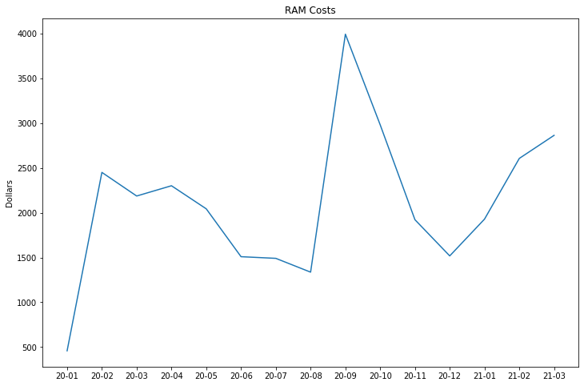

```python
plt.figure(figsize = (12,8))
plt.plot(dates, RAM_costs)
plt.title("RAM Costs")
plt.ylabel("Dollars");
```

```python
datahub = [i[i["Project name"] == "ucb-datahub-2018"] for i in master]
```

```python
CPU_intances = [i[(i["SKU description"].str.contains(r"(N1)|(E2)")) & ~(i["SKU description"].str.contains("Ram"))]
                for i in datahub]
```

```python
CPU_intances_costs = [i["Cost ($)"].sum() for i in CPU_intances]
CPU_intances_costs
```

```
[514.31,
 2661.41,
 2348.81,
 2439.16,
 2134.4799999999996,
 1492.24,
 1341.1000000000001,
 1296.8599999999997,
 4318.56,
 3368.1899999999996,
 2294.9700000000003,
 1862.0299999999997,
 2334.1900000000005,
 3011.9400000000005,
 3275.7899999999986]
```

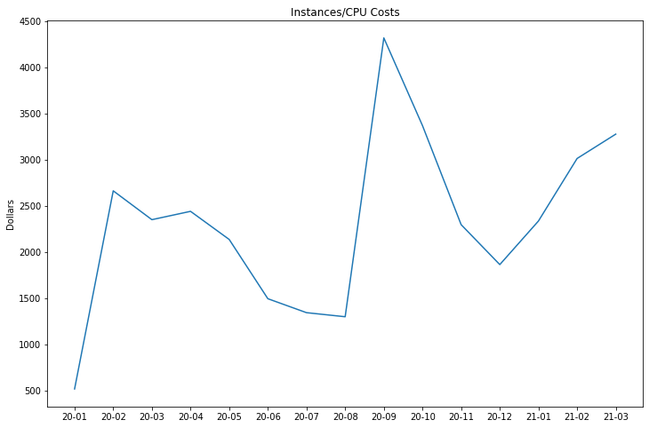

```python
plt.figure(figsize = (12,8))
plt.plot(dates, CPU_intances_costs)
plt.title("Instances/CPU Costs")
plt.ylabel("Dollars");
```

RAM and instance costs track each other very closely in value and movement.

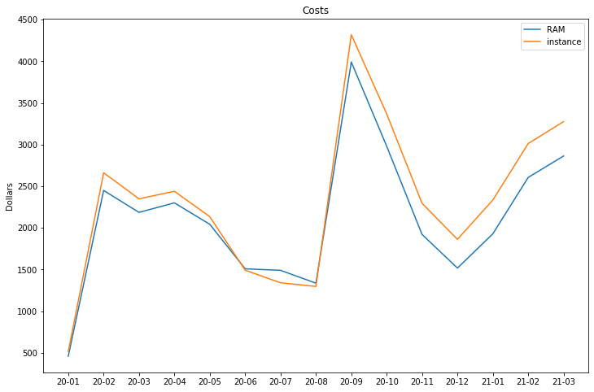

```python
plt.figure(figsize = (12,8))
plt.plot(dates, RAM_costs, label = "RAM")
plt.plot(dates, CPU_intances_costs, label = "instance")
plt.title("Costs")
plt.ylabel("Dollars")
plt.legend();
```

Since they track each other very closely, I will model Memory Usage data with RAM costs. CPU costs should be similar.

### Memory usage

Some hubs had no data like stat89a, genomics, utoronto hub Buds hub was doing something weird.

```python
hubs = listdir("../data/grafana")
if ".DS_Store" in hubs:
    hubs.remove(".DS_Store")
hubs
```

```
['prob140hub',
 'datahub',
 'data100hub',
 'data102hub',
 'rhub',
 'eecshub',
 'biology']
```

```python
memory = []
for hub in hubs:
    l = listdir("../data/grafana/" + hub)
    name = [i for i in l if 'memory' in i][0]
    temp = pd.read_csv("../data/grafana/" + hub + "/" + name)

    assert temp.columns[0] == 'Time'
    assert temp.columns[1] == 'Value'

    temp = temp.rename(columns = {"Value": name[:-4]})
    temp["Time"] = pd.to_datetime(temp["Time"])
    memory.append(temp)
```

```python
for i in range(1, len(memory)):
    try:
        assert memory[0]["Time"].where(memory[0]["Time"].values == memory[i]["Time"].values).notna().sum() == 733
    except:
        print(hubs[i])
```

```
data102hub
```

As shown below, data102 timestamps are one hour off. Need to rectify for analysis.

```python
memory[2]
```

|  | Time | data100_memory |
| --- | --- | --- |
| 0 | 2020-10-13 23:00:00 | 4.294656e+08 |
| 1 | 2020-10-14 05:00:00 | 4.294656e+08 |
| 2 | 2020-10-14 11:00:00 | 4.294656e+08 |
| 3 | 2020-10-14 17:00:00 | 4.295229e+08 |
| 4 | 2020-10-14 23:00:00 | 4.291625e+08 |
| ... | ... | ... |
| 728 | 2021-04-13 23:00:00 | 1.433711e+09 |
| 729 | 2021-04-14 05:00:00 | 1.461375e+09 |
| 730 | 2021-04-14 11:00:00 | 1.491956e+09 |
| 731 | 2021-04-14 17:00:00 | 1.586500e+09 |
| 732 | 2021-04-14 23:00:00 | 1.725018e+09 |

733 rows × 2 columns

```python
memory[3]
```

|  | Time | data102_memory |
| --- | --- | --- |
| 0 | 2020-10-14 00:00:00 | 221974528.0 |
| 1 | 2020-10-14 06:00:00 | 221974528.0 |
| 2 | 2020-10-14 12:00:00 | 221974528.0 |
| 3 | 2020-10-14 18:00:00 | 224227328.0 |
| 4 | 2020-10-15 00:00:00 | 230748160.0 |
| ... | ... | ... |
| 727 | 2021-04-13 18:00:00 | 325992448.0 |
| 728 | 2021-04-14 00:00:00 | 358162432.0 |
| 729 | 2021-04-14 06:00:00 | 373301248.0 |
| 730 | 2021-04-14 12:00:00 | 389521408.0 |
| 731 | 2021-04-14 18:00:00 | 433160192.0 |

732 rows × 2 columns

offset Data102 by an hour

```python
memory[3]["Time"] = memory[3]["Time"].apply(lambda x: x - timedelta(hours=1))
```

```python
memory = [i.loc[:731] for i in memory]
[i.shape for i in memory]
```

```
[(732, 2), (732, 2), (732, 2), (732, 2), (732, 2), (732, 2), (732, 2)]
```

```python
memory = [i.loc[:731] for i in memory]
for i in range(1, len(memory)):
    try:
        assert memory[0]["Time"].where(memory[0]["Time"].values == memory[i]["Time"].values).notna().sum() == 732
    except:
        print(hubs[i])
```

We can now merge the data on time axis. Note, for a given date data is recorded on multiple timestamps. So we only have value on that timestamp as a flow variable.

```python
memory_merged = reduce(lambda  left,right: pd.merge(left,right,on=['Time'],
                                            how='outer'), memory)
memory_merged["date"] = memory_merged.Time.dt.date
memory_merged["weekday"] = memory_merged.Time.dt.weekday
memory_merged
```

|  | Time | prob140_memory | datahub_memory | data100_memory | data102_memory | rhub_memory | eecs_memory | biology_memory | date | weekday |
| --- | --- | --- | --- | --- | --- | --- | --- | --- | --- | --- |
| 0 | 2020-10-13 23:00:00 | 3.054674e+08 | 6.187909e+08 | 4.294656e+08 | 221974528.0 | 363470848.0 | 2.820260e+08 | 217169920.0 | 2020-10-13 | 1 |
| 1 | 2020-10-14 05:00:00 | 3.054674e+08 | 6.206751e+08 | 4.294656e+08 | 221974528.0 | 365666304.0 | 2.820260e+08 | 217497600.0 | 2020-10-14 | 2 |
| 2 | 2020-10-14 11:00:00 | 3.034767e+08 | 6.704824e+08 | 4.294656e+08 | 221974528.0 | 366845952.0 | 2.820260e+08 | 185896960.0 | 2020-10-14 | 2 |
| 3 | 2020-10-14 17:00:00 | 3.037471e+08 | 6.971064e+08 | 4.295229e+08 | 224227328.0 | 379854848.0 | 2.820751e+08 | 189411328.0 | 2020-10-14 | 2 |
| 4 | 2020-10-14 23:00:00 | 3.040174e+08 | 6.964265e+08 | 4.291625e+08 | 230748160.0 | 377233408.0 | 2.828124e+08 | 216829952.0 | 2020-10-14 | 2 |
| ... | ... | ... | ... | ... | ... | ... | ... | ... | ... | ... |
| 727 | 2021-04-13 17:00:00 | 1.053299e+09 | 2.545361e+09 | 1.368519e+09 | 325992448.0 | 533839872.0 | 8.425021e+08 | 200253440.0 | 2021-04-13 | 1 |
| 728 | 2021-04-13 23:00:00 | 1.080332e+09 | 2.994397e+09 | 1.433711e+09 | 358162432.0 | 606486528.0 | 9.848054e+08 | 200253440.0 | 2021-04-13 | 1 |
| 729 | 2021-04-14 05:00:00 | 1.089524e+09 | 3.158114e+09 | 1.461375e+09 | 373301248.0 | 613515264.0 | 1.045852e+09 | 200253440.0 | 2021-04-14 | 2 |
| 730 | 2021-04-14 11:00:00 | 1.091146e+09 | 3.362464e+09 | 1.491956e+09 | 389521408.0 | 627302400.0 | 1.162031e+09 | 200253440.0 | 2021-04-14 | 2 |
| 731 | 2021-04-14 17:00:00 | 1.102770e+09 | 4.097827e+09 | 1.586500e+09 | 433160192.0 | 662282240.0 | 1.397879e+09 | 202686464.0 | 2021-04-14 | 2 |

732 rows × 10 columns

Since we care about the proportion of costs attributed to hub, if we take the max usage from timestamps of a hub for a day, we will still get an unbiased estimate for proportion.

```python
memory_daily_raw = memory_merged.groupby("date").max().drop(columns = ["Time", "weekday"])
memory_daily_raw["daily_total"] = memory_daily_raw.sum(axis = 1)
memory_daily_raw = memory_daily_raw.reset_index()
memory_daily_raw["date"] = pd.to_datetime(memory_daily_raw["date"]).dt.date
memory_daily_raw
```

|  | date | prob140_memory | datahub_memory | data100_memory | data102_memory | rhub_memory | eecs_memory | biology_memory | daily_total |
| --- | --- | --- | --- | --- | --- | --- | --- | --- | --- |
| 0 | 2020-10-13 | 3.054674e+08 | 6.187909e+08 | 4.294656e+08 | 221974528.0 | 363470848.0 | 2.820260e+08 | 217169920.0 | 2.438365e+09 |
| 1 | 2020-10-14 | 3.054674e+08 | 6.971064e+08 | 4.295229e+08 | 230748160.0 | 379854848.0 | 2.828124e+08 | 217497600.0 | 2.543010e+09 |
| 2 | 2020-10-15 | 3.045581e+08 | 7.001375e+08 | 5.275402e+08 | 240898048.0 | 379125760.0 | 2.828124e+08 | 222507008.0 | 2.657579e+09 |
| 3 | 2020-10-16 | 3.055329e+08 | 8.117207e+08 | 5.271798e+08 | 241438720.0 | 380936192.0 | 2.637660e+08 | 215400448.0 | 2.745975e+09 |
| 4 | 2020-10-17 | 3.058033e+08 | 8.068301e+08 | 5.273600e+08 | 241438720.0 | 380616704.0 | 2.642248e+08 | 215400448.0 | 2.741674e+09 |
| ... | ... | ... | ... | ... | ... | ... | ... | ... | ... |
| 179 | 2021-04-10 | 4.864819e+08 | 1.066287e+09 | 1.647493e+09 | 336904192.0 | 758837248.0 | 1.171345e+09 | 217894912.0 | 5.685244e+09 |
| 180 | 2021-04-11 | 6.750863e+08 | 1.647837e+09 | 1.893007e+09 | 373374976.0 | 812322816.0 | 1.244336e+09 | 217894912.0 | 6.863860e+09 |
| 181 | 2021-04-12 | 9.545605e+08 | 1.726390e+09 | 1.176924e+09 | 278315008.0 | 466100224.0 | 6.933504e+08 | 198901760.0 | 5.494542e+09 |
| 182 | 2021-04-13 | 1.080332e+09 | 2.994397e+09 | 1.433711e+09 | 358162432.0 | 606486528.0 | 9.848054e+08 | 200253440.0 | 7.658148e+09 |
| 183 | 2021-04-14 | 1.102770e+09 | 4.097827e+09 | 1.586500e+09 | 433160192.0 | 662282240.0 | 1.397879e+09 | 202686464.0 | 9.483104e+09 |

184 rows × 9 columns

The hub values are the max recorded usage on that day used as a proxy for the actual usage of the day. the Daily total is the sum of all hubs for the day.

In the following table, i divide a hubs value for a given day to calculate the proportion for the total usage for the day.

```python
memory_daily = memory_merged.groupby("date").max().drop(columns = ["Time", "weekday"])
daily_total = memory_daily.sum(axis = 1)
for col in memory_daily.columns:
    memory_daily[col] = memory_daily[col]/daily_total
memory_daily["daily_total"] = daily_total.values
memory_daily = memory_daily.reset_index()
memory_daily["date"] = pd.to_datetime(memory_daily["date"])
memory_daily
```

|  | date | prob140_memory | datahub_memory | data100_memory | data102_memory | rhub_memory | eecs_memory | biology_memory | daily_total |
| --- | --- | --- | --- | --- | --- | --- | --- | --- | --- |
| 0 | 2020-10-13 | 0.125275 | 0.253773 | 0.176128 | 0.091034 | 0.149063 | 0.115662 | 0.089064 | 2.438365e+09 |
| 1 | 2020-10-14 | 0.120120 | 0.274127 | 0.168903 | 0.090738 | 0.149372 | 0.111212 | 0.085528 | 2.543010e+09 |
| 2 | 2020-10-15 | 0.114600 | 0.263449 | 0.198504 | 0.090646 | 0.142658 | 0.106417 | 0.083725 | 2.657579e+09 |
| 3 | 2020-10-16 | 0.111266 | 0.295604 | 0.191983 | 0.087925 | 0.138725 | 0.096056 | 0.078442 | 2.745975e+09 |
| 4 | 2020-10-17 | 0.111539 | 0.294284 | 0.192350 | 0.088063 | 0.138826 | 0.096374 | 0.078565 | 2.741674e+09 |
| ... | ... | ... | ... | ... | ... | ... | ... | ... | ... |
| 179 | 2021-04-10 | 0.085569 | 0.187553 | 0.289784 | 0.059259 | 0.133475 | 0.206033 | 0.038326 | 5.685244e+09 |
| 180 | 2021-04-11 | 0.098354 | 0.240074 | 0.275793 | 0.054397 | 0.118348 | 0.181288 | 0.031745 | 6.863860e+09 |
| 181 | 2021-04-12 | 0.173729 | 0.314201 | 0.214199 | 0.050653 | 0.084830 | 0.126189 | 0.036200 | 5.494542e+09 |
| 182 | 2021-04-13 | 0.141070 | 0.391008 | 0.187214 | 0.046769 | 0.079195 | 0.128596 | 0.026149 | 7.658148e+09 |
| 183 | 2021-04-14 | 0.116288 | 0.432119 | 0.167297 | 0.045677 | 0.069838 | 0.147407 | 0.021373 | 9.483104e+09 |

184 rows × 9 columns

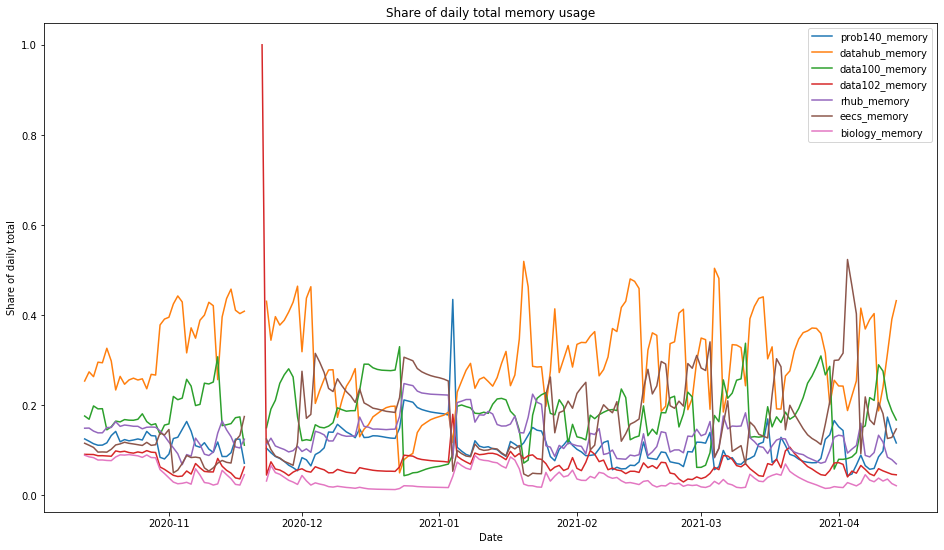

```python
cols = ['prob140_memory', 'datahub_memory', 'data100_memory',
       'data102_memory', 'rhub_memory', 'eecs_memory', 'biology_memory']
plt.figure(figsize = (16,9))
for col in cols:
    plt.plot(memory_daily["date"].values, memory_daily[col].values, label = col)
plt.legend()
plt.xlabel("Date")
plt.ylabel("Share of daily total")
plt.title("Share of daily total memory usage");
```

Note

Thre is roughly one week of no data.

Eecs hub spiked this semester (spring 2021

There are some weird spikes at end of december in some hubs.

```python
# Avg daily proportion for the entire period
memory_daily.describe().iloc[1:3]
```

|  | prob140_memory | datahub_memory | data100_memory | data102_memory | rhub_memory | eecs_memory | biology_memory | daily_total |
| --- | --- | --- | --- | --- | --- | --- | --- | --- |
| mean | 0.111351 | 0.302020 | 0.178935 | 0.072090 | 0.133173 | 0.169217 | 0.038370 | 6.883474e+09 |
| std | 0.042162 | 0.096381 | 0.063282 | 0.072099 | 0.040836 | 0.084598 | 0.022208 | 3.534806e+09 |

```python
# Avg daily proportion for fall 2020
memory_daily[memory_daily.date <= datetime.date(year=2020,month=12,day=18)].describe().iloc[1:3]
```

|  | prob140_memory | datahub_memory | data100_memory | data102_memory | rhub_memory | eecs_memory | biology_memory | daily_total |
| --- | --- | --- | --- | --- | --- | --- | --- | --- |
| mean | 0.113102 | 0.319441 | 0.192357 | 0.079694 | 0.128221 | 0.136329 | 0.045463 | 5.955049e+09 |
| std | 0.025621 | 0.091339 | 0.048133 | 0.118359 | 0.024080 | 0.068045 | 0.026881 | 3.771075e+09 |

```python
# Avg daily proportion for sp 2021
memory_daily[memory_daily.date >= datetime.date(year=2021,month=1,day=18)].describe().iloc[1:3]
```

|  | prob140_memory | datahub_memory | data100_memory | data102_memory | rhub_memory | eecs_memory | biology_memory | daily_total |
| --- | --- | --- | --- | --- | --- | --- | --- | --- |
| mean | 0.096300 | 0.325022 | 0.176785 | 0.063016 | 0.116765 | 0.190097 | 0.032016 | 7.378497e+09 |
| std | 0.029522 | 0.085018 | 0.061214 | 0.016901 | 0.032438 | 0.088687 | 0.012572 | 2.654660e+09 |

You can see that EECS hub rose in share the most Datahub rose marginally. Rest fell.

```python
# Average daily memory usage (raw absolute value) for entire data
memory_daily_raw.describe().iloc[1:3]
```

|  | prob140_memory | datahub_memory | data100_memory | data102_memory | rhub_memory | eecs_memory | biology_memory | daily_total |
| --- | --- | --- | --- | --- | --- | --- | --- | --- |
| mean | 8.102571e+08 | 2.054871e+09 | 1.277900e+09 | 4.384629e+08 | 9.460176e+08 | 1.303737e+09 | 2.027583e+08 | 6.883474e+09 |
| std | 5.643058e+08 | 1.074895e+09 | 9.524316e+08 | 2.111193e+08 | 6.268972e+08 | 1.040166e+09 | 9.563953e+06 | 3.534806e+09 |

```python
# Average daily memory usage (raw absolute value) for fall 2020
a = memory_daily_raw[memory_daily_raw.date <= datetime.date(year=2020,month=12,day=18)].describe().iloc[1:3]
a
```

|  | prob140_memory | datahub_memory | data100_memory | data102_memory | rhub_memory | eecs_memory | biology_memory | daily_total |
| --- | --- | --- | --- | --- | --- | --- | --- | --- |
| mean | 7.397385e+08 | 1.952280e+09 | 1.298100e+09 | 3.647560e+08 | 7.910544e+08 | 9.784966e+08 | 2.029329e+08 | 5.955049e+09 |
| std | 5.216770e+08 | 1.067101e+09 | 9.652677e+08 | 1.696678e+08 | 4.985486e+08 | 9.217801e+08 | 1.002807e+07 | 3.771075e+09 |

```python
# Average daily memory usage (raw absolute value) for sp21
b = memory_daily_raw[memory_daily_raw.date >= datetime.date(year=2021,month=1,day=18)].describe().iloc[1:3]
b
```

|  | prob140_memory | datahub_memory | data100_memory | data102_memory | rhub_memory | eecs_memory | biology_memory | daily_total |
| --- | --- | --- | --- | --- | --- | --- | --- | --- |
| mean | 7.175805e+08 | 2.391320e+09 | 1.305646e+09 | 4.495508e+08 | 8.799968e+08 | 1.428589e+09 | 2.058139e+08 | 7.378497e+09 |
| std | 3.875166e+08 | 1.019214e+09 | 7.603822e+08 | 1.815177e+08 | 4.753071e+08 | 9.710493e+08 | 8.741258e+06 | 2.654660e+09 |

$ increase in average daily memory usage for spring 21 compared to fall 20

```python
(b.loc["mean"]/a.loc["mean"] - 1)*100
```

```
prob140_memory    -2.995391
datahub_memory    22.488630
data100_memory     0.581366
data102_memory    23.247012
rhub_memory       11.243534
eecs_memory       45.998332
biology_memory     1.419651
daily_total       23.903221
Name: mean, dtype: float64
```

Note:

Spring semester has much higher usage overall. Most hubs average usage went up (except prob140).

The reaseon that EECS hub as a share fo daily increased so much in sp21 is becuase is grew much more than others. Thats why as a %, shares of other hubs were down.

```python
memory_daily["month"] = memory_daily.date.dt.month
memory_daily["weekday"] = memory_daily.date.dt.weekday
memory_daily
```

|  | date | prob140_memory | datahub_memory | data100_memory | data102_memory | rhub_memory | eecs_memory | biology_memory | daily_total | month | weekday |
| --- | --- | --- | --- | --- | --- | --- | --- | --- | --- | --- | --- |
| 0 | 2020-10-13 | 0.125275 | 0.253773 | 0.176128 | 0.091034 | 0.149063 | 0.115662 | 0.089064 | 2.438365e+09 | 10 | 1 |
| 1 | 2020-10-14 | 0.120120 | 0.274127 | 0.168903 | 0.090738 | 0.149372 | 0.111212 | 0.085528 | 2.543010e+09 | 10 | 2 |
| 2 | 2020-10-15 | 0.114600 | 0.263449 | 0.198504 | 0.090646 | 0.142658 | 0.106417 | 0.083725 | 2.657579e+09 | 10 | 3 |
| 3 | 2020-10-16 | 0.111266 | 0.295604 | 0.191983 | 0.087925 | 0.138725 | 0.096056 | 0.078442 | 2.745975e+09 | 10 | 4 |
| 4 | 2020-10-17 | 0.111539 | 0.294284 | 0.192350 | 0.088063 | 0.138826 | 0.096374 | 0.078565 | 2.741674e+09 | 10 | 5 |
| ... | ... | ... | ... | ... | ... | ... | ... | ... | ... | ... | ... |
| 179 | 2021-04-10 | 0.085569 | 0.187553 | 0.289784 | 0.059259 | 0.133475 | 0.206033 | 0.038326 | 5.685244e+09 | 4 | 5 |
| 180 | 2021-04-11 | 0.098354 | 0.240074 | 0.275793 | 0.054397 | 0.118348 | 0.181288 | 0.031745 | 6.863860e+09 | 4 | 6 |
| 181 | 2021-04-12 | 0.173729 | 0.314201 | 0.214199 | 0.050653 | 0.084830 | 0.126189 | 0.036200 | 5.494542e+09 | 4 | 0 |
| 182 | 2021-04-13 | 0.141070 | 0.391008 | 0.187214 | 0.046769 | 0.079195 | 0.128596 | 0.026149 | 7.658148e+09 | 4 | 1 |
| 183 | 2021-04-14 | 0.116288 | 0.432119 | 0.167297 | 0.045677 | 0.069838 | 0.147407 | 0.021373 | 9.483104e+09 | 4 | 2 |

184 rows × 11 columns

Over here, i calcuate `monthly_sum`. This is the sum of the `daily_total` usage for the month.

```python
memory_daily = memory_daily.join(memory_daily.groupby('month')['daily_total'].sum(), on='month', rsuffix='_r')
memory_daily = memory_daily.rename(columns = {"daily_total_r": "monthly_sum"})
memory_daily
```

|  | date | prob140_memory | datahub_memory | data100_memory | data102_memory | rhub_memory | eecs_memory | biology_memory | daily_total | month | weekday | monthly_sum |
| --- | --- | --- | --- | --- | --- | --- | --- | --- | --- | --- | --- | --- |
| 0 | 2020-10-13 | 0.125275 | 0.253773 | 0.176128 | 0.091034 | 0.149063 | 0.115662 | 0.089064 | 2.438365e+09 | 10 | 1 | 4.898803e+10 |
| 1 | 2020-10-14 | 0.120120 | 0.274127 | 0.168903 | 0.090738 | 0.149372 | 0.111212 | 0.085528 | 2.543010e+09 | 10 | 2 | 4.898803e+10 |
| 2 | 2020-10-15 | 0.114600 | 0.263449 | 0.198504 | 0.090646 | 0.142658 | 0.106417 | 0.083725 | 2.657579e+09 | 10 | 3 | 4.898803e+10 |
| 3 | 2020-10-16 | 0.111266 | 0.295604 | 0.191983 | 0.087925 | 0.138725 | 0.096056 | 0.078442 | 2.745975e+09 | 10 | 4 | 4.898803e+10 |
| 4 | 2020-10-17 | 0.111539 | 0.294284 | 0.192350 | 0.088063 | 0.138826 | 0.096374 | 0.078565 | 2.741674e+09 | 10 | 5 | 4.898803e+10 |
| ... | ... | ... | ... | ... | ... | ... | ... | ... | ... | ... | ... | ... |
| 179 | 2021-04-10 | 0.085569 | 0.187553 | 0.289784 | 0.059259 | 0.133475 | 0.206033 | 0.038326 | 5.685244e+09 | 4 | 5 | 1.120309e+11 |
| 180 | 2021-04-11 | 0.098354 | 0.240074 | 0.275793 | 0.054397 | 0.118348 | 0.181288 | 0.031745 | 6.863860e+09 | 4 | 6 | 1.120309e+11 |
| 181 | 2021-04-12 | 0.173729 | 0.314201 | 0.214199 | 0.050653 | 0.084830 | 0.126189 | 0.036200 | 5.494542e+09 | 4 | 0 | 1.120309e+11 |
| 182 | 2021-04-13 | 0.141070 | 0.391008 | 0.187214 | 0.046769 | 0.079195 | 0.128596 | 0.026149 | 7.658148e+09 | 4 | 1 | 1.120309e+11 |
| 183 | 2021-04-14 | 0.116288 | 0.432119 | 0.167297 | 0.045677 | 0.069838 | 0.147407 | 0.021373 | 9.483104e+09 | 4 | 2 | 1.120309e+11 |

184 rows × 12 columns

Here I take the share a day of the usage for the month.

```python
memory_daily["share_of_month"] = memory_daily.daily_total / memory_daily.monthly_sum
memory_daily
```

|  | date | prob140_memory | datahub_memory | data100_memory | data102_memory | rhub_memory | eecs_memory | biology_memory | daily_total | month | weekday | monthly_sum | share_of_month |
| --- | --- | --- | --- | --- | --- | --- | --- | --- | --- | --- | --- | --- | --- |
| 0 | 2020-10-13 | 0.125275 | 0.253773 | 0.176128 | 0.091034 | 0.149063 | 0.115662 | 0.089064 | 2.438365e+09 | 10 | 1 | 4.898803e+10 | 0.049775 |
| 1 | 2020-10-14 | 0.120120 | 0.274127 | 0.168903 | 0.090738 | 0.149372 | 0.111212 | 0.085528 | 2.543010e+09 | 10 | 2 | 4.898803e+10 | 0.051911 |
| 2 | 2020-10-15 | 0.114600 | 0.263449 | 0.198504 | 0.090646 | 0.142658 | 0.106417 | 0.083725 | 2.657579e+09 | 10 | 3 | 4.898803e+10 | 0.054250 |
| 3 | 2020-10-16 | 0.111266 | 0.295604 | 0.191983 | 0.087925 | 0.138725 | 0.096056 | 0.078442 | 2.745975e+09 | 10 | 4 | 4.898803e+10 | 0.056054 |
| 4 | 2020-10-17 | 0.111539 | 0.294284 | 0.192350 | 0.088063 | 0.138826 | 0.096374 | 0.078565 | 2.741674e+09 | 10 | 5 | 4.898803e+10 | 0.055966 |
| ... | ... | ... | ... | ... | ... | ... | ... | ... | ... | ... | ... | ... | ... |
| 179 | 2021-04-10 | 0.085569 | 0.187553 | 0.289784 | 0.059259 | 0.133475 | 0.206033 | 0.038326 | 5.685244e+09 | 4 | 5 | 1.120309e+11 | 0.050747 |
| 180 | 2021-04-11 | 0.098354 | 0.240074 | 0.275793 | 0.054397 | 0.118348 | 0.181288 | 0.031745 | 6.863860e+09 | 4 | 6 | 1.120309e+11 | 0.061268 |
| 181 | 2021-04-12 | 0.173729 | 0.314201 | 0.214199 | 0.050653 | 0.084830 | 0.126189 | 0.036200 | 5.494542e+09 | 4 | 0 | 1.120309e+11 | 0.049045 |
| 182 | 2021-04-13 | 0.141070 | 0.391008 | 0.187214 | 0.046769 | 0.079195 | 0.128596 | 0.026149 | 7.658148e+09 | 4 | 1 | 1.120309e+11 | 0.068357 |
| 183 | 2021-04-14 | 0.116288 | 0.432119 | 0.167297 | 0.045677 | 0.069838 | 0.147407 | 0.021373 | 9.483104e+09 | 4 | 2 | 1.120309e+11 | 0.084647 |

184 rows × 13 columns

Usage data for the months of October and April are for half of the month each. So, I am remvoing those from analysis. (We also dont have costs for April)

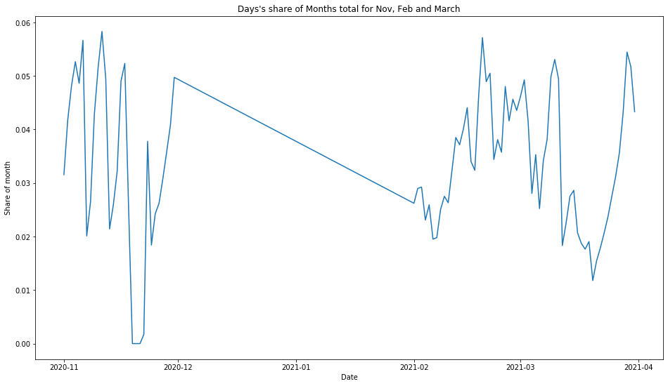

```python
temp = memory_daily[memory_daily.month.isin([11,2,3])]
plt.figure(figsize = (16,9))
plt.plot(temp["date"].values, temp["share_of_month"].values)
plt.xlabel("Date")
plt.ylabel("Share of month")
plt.title("Days's share of Months total for Nov, Feb and March");
```

```python
feat = ["month", "weekday" , "monthly_sum" , "share_of_month"]
for f in feat:
    memory_daily_raw[f] = memory_daily[f]
memory_daily_raw
```

|  | date | prob140_memory | datahub_memory | data100_memory | data102_memory | rhub_memory | eecs_memory | biology_memory | daily_total | month | weekday | monthly_sum | share_of_month |
| --- | --- | --- | --- | --- | --- | --- | --- | --- | --- | --- | --- | --- | --- |
| 0 | 2020-10-13 | 3.054674e+08 | 6.187909e+08 | 4.294656e+08 | 221974528.0 | 363470848.0 | 2.820260e+08 | 217169920.0 | 2.438365e+09 | 10 | 1 | 4.898803e+10 | 0.049775 |
| 1 | 2020-10-14 | 3.054674e+08 | 6.971064e+08 | 4.295229e+08 | 230748160.0 | 379854848.0 | 2.828124e+08 | 217497600.0 | 2.543010e+09 | 10 | 2 | 4.898803e+10 | 0.051911 |
| 2 | 2020-10-15 | 3.045581e+08 | 7.001375e+08 | 5.275402e+08 | 240898048.0 | 379125760.0 | 2.828124e+08 | 222507008.0 | 2.657579e+09 | 10 | 3 | 4.898803e+10 | 0.054250 |
| 3 | 2020-10-16 | 3.055329e+08 | 8.117207e+08 | 5.271798e+08 | 241438720.0 | 380936192.0 | 2.637660e+08 | 215400448.0 | 2.745975e+09 | 10 | 4 | 4.898803e+10 | 0.056054 |
| 4 | 2020-10-17 | 3.058033e+08 | 8.068301e+08 | 5.273600e+08 | 241438720.0 | 380616704.0 | 2.642248e+08 | 215400448.0 | 2.741674e+09 | 10 | 5 | 4.898803e+10 | 0.055966 |
| ... | ... | ... | ... | ... | ... | ... | ... | ... | ... | ... | ... | ... | ... |
| 179 | 2021-04-10 | 4.864819e+08 | 1.066287e+09 | 1.647493e+09 | 336904192.0 | 758837248.0 | 1.171345e+09 | 217894912.0 | 5.685244e+09 | 4 | 5 | 1.120309e+11 | 0.050747 |
| 180 | 2021-04-11 | 6.750863e+08 | 1.647837e+09 | 1.893007e+09 | 373374976.0 | 812322816.0 | 1.244336e+09 | 217894912.0 | 6.863860e+09 | 4 | 6 | 1.120309e+11 | 0.061268 |
| 181 | 2021-04-12 | 9.545605e+08 | 1.726390e+09 | 1.176924e+09 | 278315008.0 | 466100224.0 | 6.933504e+08 | 198901760.0 | 5.494542e+09 | 4 | 0 | 1.120309e+11 | 0.049045 |
| 182 | 2021-04-13 | 1.080332e+09 | 2.994397e+09 | 1.433711e+09 | 358162432.0 | 606486528.0 | 9.848054e+08 | 200253440.0 | 7.658148e+09 | 4 | 1 | 1.120309e+11 | 0.068357 |
| 183 | 2021-04-14 | 1.102770e+09 | 4.097827e+09 | 1.586500e+09 | 433160192.0 | 662282240.0 | 1.397879e+09 | 202686464.0 | 9.483104e+09 | 4 | 2 | 1.120309e+11 | 0.084647 |

184 rows × 13 columns

I have added a column for weekday. 0 is monday, 6 sunday. This is to check which day of the week has greatest usage.

Following is average usage on a given weekday.

```python
weekday_raw = memory_daily_raw.groupby("weekday").mean().drop(columns = ["month","monthly_sum","share_of_month"])
weekday_raw
```

| weekday | prob140_memory | datahub_memory | data100_memory | data102_memory | rhub_memory | eecs_memory | biology_memory | daily_total |
| --- | --- | --- | --- | --- | --- | --- | --- | --- |
| 0 | 8.950872e+08 | 2.232378e+09 | 1.282118e+09 | 4.293158e+08 | 8.882718e+08 | 1.308024e+09 | 2.007747e+08 | 7.235969e+09 |
| 1 | 8.242299e+08 | 2.102036e+09 | 1.384379e+09 | 4.233515e+08 | 9.151722e+08 | 1.242574e+09 | 2.024512e+08 | 7.094193e+09 |
| 2 | 7.882165e+08 | 2.090153e+09 | 1.242124e+09 | 4.304618e+08 | 8.930855e+08 | 1.286775e+09 | 2.033289e+08 | 6.934145e+09 |
| 3 | 8.025860e+08 | 2.116906e+09 | 1.328063e+09 | 4.765712e+08 | 9.754326e+08 | 1.202040e+09 | 2.039864e+08 | 6.832293e+09 |
| 4 | 8.167121e+08 | 2.062061e+09 | 1.246376e+09 | 4.463641e+08 | 9.964955e+08 | 1.343249e+09 | 2.044774e+08 | 6.842053e+09 |
| 5 | 7.407359e+08 | 1.736869e+09 | 1.204348e+09 | 4.188479e+08 | 9.638406e+08 | 1.336401e+09 | 2.029196e+08 | 6.349963e+09 |
| 6 | 8.014843e+08 | 2.029997e+09 | 1.252067e+09 | 4.462318e+08 | 9.988371e+08 | 1.413176e+09 | 2.014278e+08 | 6.885644e+09 |

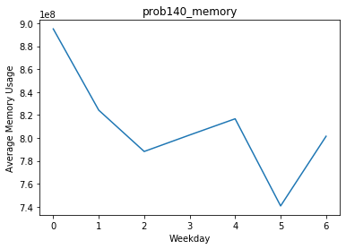

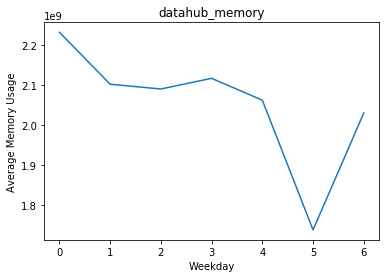

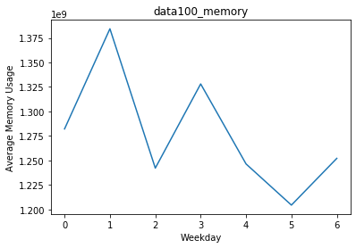

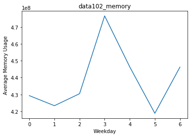

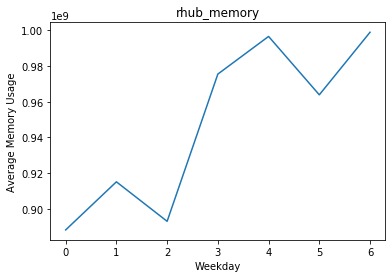

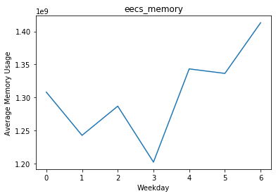

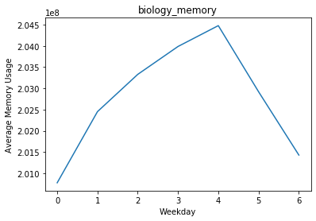

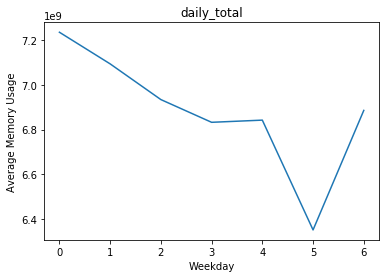

```python
for col in weekday_raw.columns:
    plt.figure()
    plt.plot(weekday_raw.index.values, weekday_raw[col], label = col)
    plt.xlabel("Weekday")
    plt.ylabel("Average Memory Usage")
    plt.title(col);
```

Most hubs have the least amount of usage on a saturday. This makes sense as assignemnts are generally not due on saturdays.

### COSTS and USAGE

Now, we will compare RAM Costs to the Memory usage figures

```python
# ram costa calcuated for the month earlier
list(zip(dates, RAM_costs))
```

```
[('20-01', 459.1),
 ('20-02', 2449.32),
 ('20-03', 2185.7999999999997),
 ('20-04', 2300.3600000000006),
 ('20-05', 2042.9299999999998),
 ('20-06', 1508.86),
 ('20-07', 1490.3799999999999),
 ('20-08', 1336.41),
 ('20-09', 3991.080000000001),
 ('20-10', 2980.58),
 ('20-11', 1921.2299999999996),
 ('20-12', 1517.7299999999998),
 ('21-01', 1928.1600000000003),
 ('21-02', 2605.3099999999995),
 ('21-03', 2862.5699999999997)]
```

```python
mapping = pd.DataFrame(zip([10,11,12,1,2,3], RAM_costs[9:]))
mapping.columns = ["month", "monthy_RAM_cost"]
mapping
```

|  | month | monthy_RAM_cost |
| --- | --- | --- |
| 0 | 10 | 2980.58 |
| 1 | 11 | 1921.23 |
| 2 | 12 | 1517.73 |
| 3 | 1 | 1928.16 |
| 4 | 2 | 2605.31 |
| 5 | 3 | 2862.57 |

```python
usage_costs = memory_daily.merge(mapping)
usage_costs = usage_costs[usage_costs.month != 10]
usage_costs
```

|  | date | prob140_memory | datahub_memory | data100_memory | data102_memory | rhub_memory | eecs_memory | biology_memory | daily_total | month | weekday | monthly_sum | share_of_month | monthy_RAM_cost |
| --- | --- | --- | --- | --- | --- | --- | --- | --- | --- | --- | --- | --- | --- | --- |
| 19 | 2020-11-01 | 0.091600 | 0.395328 | 0.158571 | 0.051081 | 0.118207 | 0.146244 | 0.038968 | 5.194854e+09 | 11 | 6 | 1.646312e+11 | 0.031554 | 1921.23 |
| 20 | 2020-11-02 | 0.126120 | 0.424803 | 0.219571 | 0.044529 | 0.105498 | 0.049985 | 0.029495 | 6.872465e+09 | 11 | 0 | 1.646312e+11 | 0.041745 | 1921.23 |
| 21 | 2020-11-03 | 0.128997 | 0.442626 | 0.212319 | 0.041880 | 0.092253 | 0.056180 | 0.025745 | 7.931699e+09 | 11 | 1 | 1.646312e+11 | 0.048179 | 1921.23 |
| 22 | 2020-11-04 | 0.146328 | 0.429224 | 0.215807 | 0.042831 | 0.068195 | 0.070850 | 0.026766 | 8.668889e+09 | 11 | 2 | 1.646312e+11 | 0.052656 | 1921.23 |
| 23 | 2020-11-05 | 0.164006 | 0.316256 | 0.257617 | 0.054103 | 0.090540 | 0.088485 | 0.028992 | 8.003138e+09 | 11 | 3 | 1.646312e+11 | 0.048613 | 1921.23 |
| ... | ... | ... | ... | ... | ... | ... | ... | ... | ... | ... | ... | ... | ... | ... |
| 165 | 2021-03-27 | 0.072651 | 0.370651 | 0.285646 | 0.051765 | 0.075617 | 0.120457 | 0.023213 | 8.524050e+09 | 3 | 5 | 2.389320e+11 | 0.035676 | 2862.57 |
| 166 | 2021-03-28 | 0.081923 | 0.359508 | 0.309519 | 0.045868 | 0.071285 | 0.112782 | 0.019116 | 1.035063e+10 | 3 | 6 | 2.389320e+11 | 0.043320 | 2862.57 |
| 167 | 2021-03-29 | 0.124382 | 0.315989 | 0.267443 | 0.044356 | 0.074290 | 0.158102 | 0.015438 | 1.300982e+10 | 3 | 0 | 2.389320e+11 | 0.054450 | 2862.57 |
| 168 | 2021-03-30 | 0.134447 | 0.201482 | 0.286364 | 0.055102 | 0.098586 | 0.207749 | 0.016270 | 1.236074e+10 | 3 | 1 | 2.389320e+11 | 0.051733 | 2862.57 |
| 169 | 2021-03-31 | 0.166044 | 0.255550 | 0.058356 | 0.071931 | 0.129153 | 0.299533 | 0.019433 | 1.034883e+10 | 3 | 2 | 2.389320e+11 | 0.043313 | 2862.57 |

151 rows × 14 columns

In the above table, I have `monthy_RAM_cost` for a month. Multiply it by `share_of_month` to get the costs for a day. Multiply it by `prob140_memory` to get the share of monthly costs attributed to prob140 hub for that day. Similarly for all hubs, as calcuated below,

```python
cols = ['prob140_memory', 'datahub_memory', 'data100_memory',
       'data102_memory', 'rhub_memory', 'eecs_memory', 'biology_memory']
for col in cols:
    usage_costs[col] = usage_costs[col] * usage_costs.share_of_month * usage_costs.monthy_RAM_cost
usage_costs
```

|  | date | prob140_memory | datahub_memory | data100_memory | data102_memory | rhub_memory | eecs_memory | biology_memory | daily_total | month | weekday | monthly_sum | share_of_month | monthy_RAM_cost |
| --- | --- | --- | --- | --- | --- | --- | --- | --- | --- | --- | --- | --- | --- | --- |
| 19 | 2020-11-01 | 5.553108 | 23.966161 | 9.613137 | 3.096718 | 7.166116 | 8.865833 | 2.362367 | 5.194854e+09 | 11 | 6 | 1.646312e+11 | 0.031554 | 1921.23 |
| 20 | 2020-11-02 | 10.114940 | 34.069630 | 17.609776 | 3.571275 | 8.461016 | 4.008836 | 2.365522 | 6.872465e+09 | 11 | 0 | 1.646312e+11 | 0.041745 | 1921.23 |
| 21 | 2020-11-03 | 11.940228 | 40.970408 | 19.652745 | 3.876525 | 8.539121 | 5.200105 | 2.383017 | 7.931699e+09 | 11 | 1 | 1.646312e+11 | 0.048179 | 1921.23 |
| 22 | 2020-11-04 | 14.803252 | 43.422448 | 21.832134 | 4.333015 | 6.898914 | 7.167550 | 2.707770 | 8.668889e+09 | 11 | 2 | 1.646312e+11 | 0.052656 | 1921.23 |
| 23 | 2020-11-05 | 15.317483 | 29.537003 | 24.060375 | 5.052977 | 8.456044 | 8.264175 | 2.707770 | 8.003138e+09 | 11 | 3 | 1.646312e+11 | 0.048613 | 1921.23 |
| ... | ... | ... | ... | ... | ... | ... | ... | ... | ... | ... | ... | ... | ... | ... |
| 165 | 2021-03-27 | 7.419381 | 37.852333 | 29.171337 | 5.286427 | 7.722357 | 12.301595 | 2.370565 | 8.524050e+09 | 3 | 5 | 2.389320e+11 | 0.035676 | 2862.57 |
| 166 | 2021-03-28 | 10.159023 | 44.581700 | 38.382713 | 5.688040 | 8.839845 | 13.985777 | 2.370565 | 1.035063e+10 | 3 | 6 | 2.389320e+11 | 0.043320 | 2862.57 |
| 167 | 2021-03-29 | 19.386986 | 49.252165 | 41.685418 | 6.913587 | 11.579389 | 24.642841 | 2.406192 | 1.300982e+10 | 3 | 0 | 2.389320e+11 | 0.054450 | 2862.57 |
| 168 | 2021-03-30 | 19.910299 | 29.837502 | 42.407673 | 8.160136 | 14.599630 | 30.765569 | 2.409430 | 1.236074e+10 | 3 | 1 | 2.389320e+11 | 0.051733 | 2862.57 |
| 169 | 2021-03-31 | 20.587211 | 31.684606 | 7.235358 | 8.918411 | 16.013126 | 37.137979 | 2.409430 | 1.034883e+10 | 3 | 2 | 2.389320e+11 | 0.043313 | 2862.57 |

151 rows × 14 columns

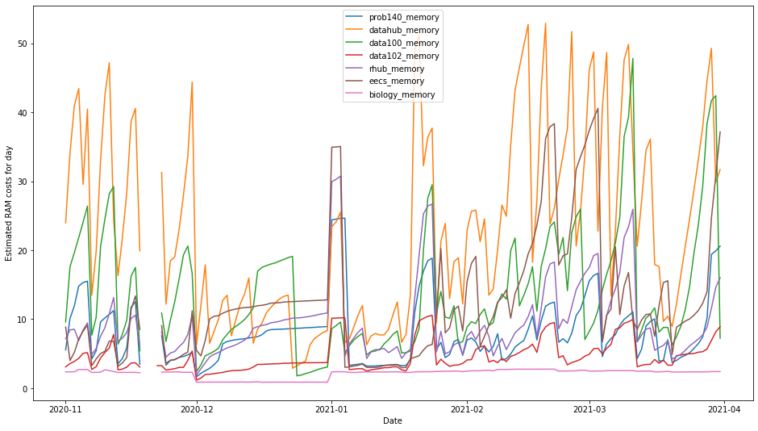

```python
cols = ['prob140_memory', 'datahub_memory', 'data100_memory',
       'data102_memory', 'rhub_memory', 'eecs_memory', 'biology_memory']
plt.figure(figsize = (16,9))
for col in cols:
    plt.plot(usage_costs["date"].values, usage_costs[col].values, label = col)
plt.legend()
plt.xlabel("Date")
plt.ylabel("Estimated RAM costs for day");
```

Note: Data 100 costs surge in march twice.

Datahub costs are high and periodic.

Use the following function to plot costs for any hub for any months.

```python
def hub_moth_RAM_cost(hubs, month):
    temp = usage_costs[usage_costs.month.isin(month)]
    plt.figure(figsize = (16,9))
    for col in hubs:
        plt.plot(temp["date"].values, temp[col].values, label = col)
    plt.legend()
    plt.xlabel("Date")
    plt.ylabel("Estimated RAM costs for day");
```

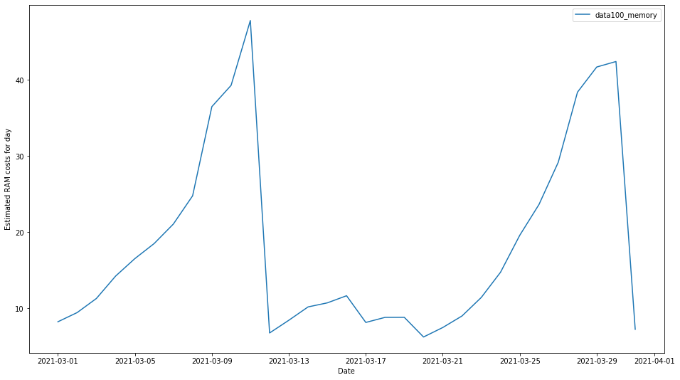

```python
hub_moth_RAM_cost(["data100_memory"], [3])
```

Note: The second surge corresponds to Data 100 HW 7 and optional competition associated with the HW. It was due spring break with no other assignment due. So we are safely say the usage iver spring break was just due to this assignement.

```python
usage_costs[usage_costs.date >= datetime.date(year=2021,month=3,day=21)].data100_memory.sum()
```

```
244.71178842205788
```

Therefore, RAM costs for data100 hw 7 are 244. With CPU, its roughly 500. (CPU is roughly the same as memory).

Note: This is an upperbound for a general HW assignment.

We can sum the daily costs to get costs for the month.

```python
usage_costs_month = usage_costs.iloc[:, 1:10].groupby("month", sort=False).sum().drop(columns = "daily_total")
usage_costs_month
```

| month | prob140_memory | datahub_memory | data100_memory | data102_memory | rhub_memory | eecs_memory | biology_memory |
| --- | --- | --- | --- | --- | --- | --- | --- |
| 11 | 204.357551 | 768.156521 | 415.171342 | 103.191943 | 202.655970 | 165.511610 | 62.185063 |
| 12 | 218.125469 | 296.829845 | 283.491826 | 93.284464 | 246.602969 | 352.023545 | 27.371881 |
| 1 | 269.172396 | 538.373508 | 290.613631 | 156.625156 | 336.212639 | 263.541917 | 73.620754 |
| 2 | 220.485559 | 871.819964 | 439.756086 | 148.080039 | 284.183060 | 567.031875 | 73.953416 |
| 3 | 280.642771 | 922.977852 | 572.009148 | 176.405058 | 342.660514 | 492.117924 | 75.756733 |

Note: Costs in march are higher than Nov for all hubs.

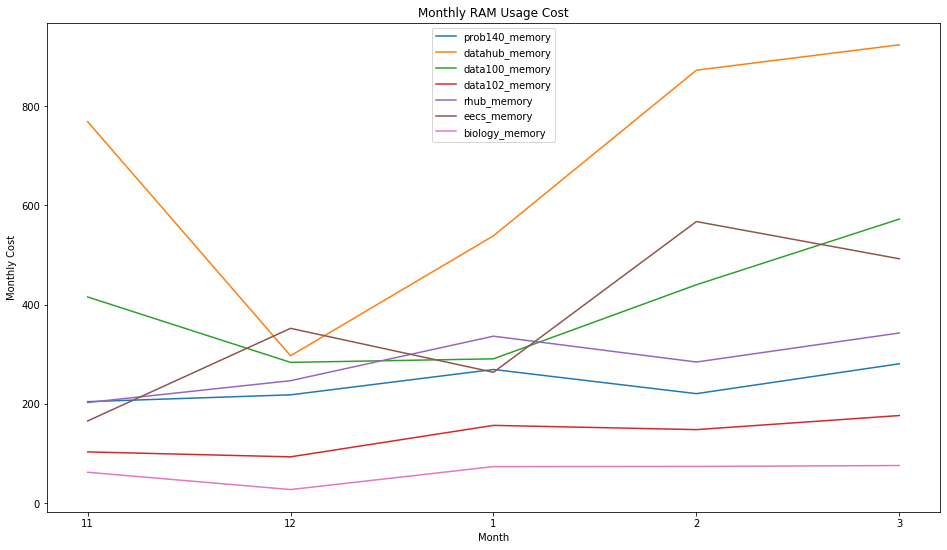

```python
plt.figure(figsize = (16,9))
for col in usage_costs_month.columns:
    plt.plot([str(i) for i in usage_costs_month.index.values], usage_costs_month[col].values, label = col)
plt.legend()
plt.title("Monthly RAM Usage Cost")
plt.xlabel("Month")
plt.ylabel("Monthly Cost");
```

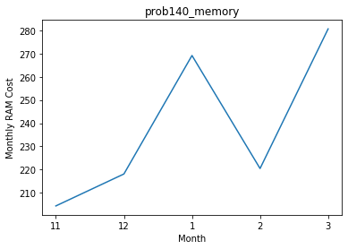

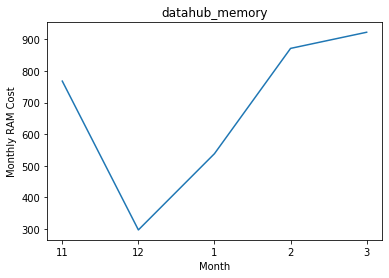

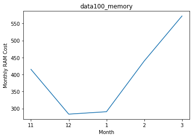

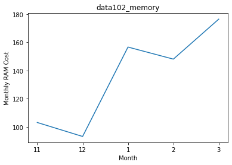

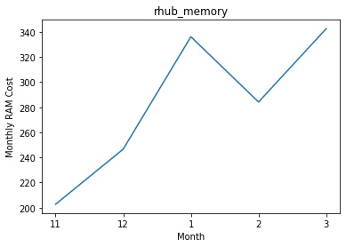

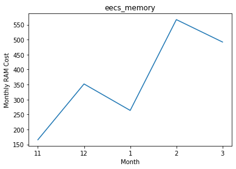

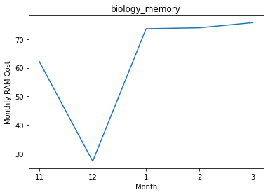

```python
for col in usage_costs_month.columns:
    plt.figure()
    plt.plot([str(i) for i in usage_costs_month.index.values], usage_costs_month[col], label = col)
    plt.xlabel("Month")
    plt.ylabel("Monthly RAM Cost")
    plt.title(col);
```

## USERS

Will try to analysze costs and why they increase. Metrics like Cost per user, Memory Usage per user, etc.

```python
# Loading the active users for hubs
users = []
for hub in hubs:
    l = listdir("../data/grafana/" + hub)
    name = [i for i in l if 'users' in i][0]
    temp = pd.read_csv("../data/grafana/" + hub + "/" + name)

    assert temp.columns[0] == 'Time'
    assert temp.columns[1] == 'Active Users'

    temp = temp.rename(columns = {"Active Users": name[:-4]})
    temp["Time"] = pd.to_datetime(temp["Time"])
    users.append(temp)
```

same time issue for data102

```python
users[3]["Time"] = users[3]["Time"].apply(lambda x: x - timedelta(hours=1))
```

```python
users = [i.loc[:731] for i in users]
[i.shape for i in users]
```

```
[(732, 2), (732, 2), (732, 2), (732, 2), (732, 2), (732, 2), (732, 2)]
```

```python
users = [i.loc[:731] for i in users]
for i in range(1, len(users)):
    try:
        assert users[0]["Time"].where(users[0]["Time"].values == users[i]["Time"].values).notna().sum() == 732
    except:
        print(hubs[i])
```

```python
users_merged = reduce(lambda  left,right: pd.merge(left,right,on=['Time'],
                                            how='outer'), users)
users_merged["date"] = users_merged.Time.dt.date
users_merged["weekday"] = users_merged.Time.dt.weekday
users_merged
```

|  | Time | prob140_users | datahub_users | data100_users | data102_users | rhub_users | eecs_users | biology_users | date | weekday |
| --- | --- | --- | --- | --- | --- | --- | --- | --- | --- | --- |
| 0 | 2020-10-13 23:00:00 | 7.0 | 481.0 | 73.0 | 28.0 | 46.0 | 29.0 | 6.0 | 2020-10-13 | 1 |
| 1 | 2020-10-14 05:00:00 | 1.0 | 97.0 | 22.0 | 6.0 | 2.0 | 11.0 | NaN | 2020-10-14 | 2 |
| 2 | 2020-10-14 11:00:00 | 9.0 | 426.0 | 36.0 | 16.0 | 87.0 | 83.0 | 4.0 | 2020-10-14 | 2 |
| 3 | 2020-10-14 17:00:00 | 16.0 | 630.0 | 102.0 | 48.0 | 102.0 | 75.0 | 4.0 | 2020-10-14 | 2 |
| 4 | 2020-10-14 23:00:00 | 17.0 | 598.0 | 112.0 | 23.0 | 51.0 | 31.0 | 3.0 | 2020-10-14 | 2 |
| ... | ... | ... | ... | ... | ... | ... | ... | ... | ... | ... |
| 727 | 2021-04-13 17:00:00 | 19.0 | 380.0 | 110.0 | 28.0 | 90.0 | 130.0 | 3.0 | 2021-04-13 | 1 |
| 728 | 2021-04-13 23:00:00 | 26.0 | 413.0 | 127.0 | 32.0 | 87.0 | 96.0 | 2.0 | 2021-04-13 | 1 |
| 729 | 2021-04-14 05:00:00 | 1.0 | 73.0 | 27.0 | 3.0 | 6.0 | 35.0 | 1.0 | 2021-04-14 | 2 |
| 730 | 2021-04-14 11:00:00 | 5.0 | 299.0 | 58.0 | 32.0 | 27.0 | 138.0 | 3.0 | 2021-04-14 | 2 |
| 731 | 2021-04-14 17:00:00 | 12.0 | 520.0 | 148.0 | 45.0 | 53.0 | 233.0 | 6.0 | 2021-04-14 | 2 |

732 rows × 10 columns

I will take max reocrded users for a day again. This keeps the unit estimates unbiased.

```python
users_daily_raw = users_merged.groupby("date").max().drop(columns = ["Time", "weekday"])
users_daily_raw["daily_total"] = users_daily_raw.sum(axis = 1)
users_daily_raw = users_daily_raw.reset_index()
users_daily_raw["date"] = pd.to_datetime(users_daily_raw["date"]).dt.date
users_daily_raw
```

|  | date | prob140_users | datahub_users | data100_users | data102_users | rhub_users | eecs_users | biology_users | daily_total |
| --- | --- | --- | --- | --- | --- | --- | --- | --- | --- |
| 0 | 2020-10-13 | 7.0 | 481.0 | 73.0 | 28.0 | 46.0 | 29.0 | 6.0 | 670.0 |
| 1 | 2020-10-14 | 17.0 | 630.0 | 112.0 | 48.0 | 102.0 | 83.0 | 4.0 | 996.0 |
| 2 | 2020-10-15 | 16.0 | 554.0 | 161.0 | 49.0 | 75.0 | 79.0 | 4.0 | 938.0 |
| 3 | 2020-10-16 | 29.0 | 597.0 | 35.0 | 36.0 | 114.0 | 78.0 | 39.0 | 928.0 |
| 4 | 2020-10-17 | 49.0 | 181.0 | 10.0 | 22.0 | 27.0 | 10.0 | 5.0 | 304.0 |
| ... | ... | ... | ... | ... | ... | ... | ... | ... | ... |
| 179 | 2021-04-10 | 37.0 | 296.0 | 54.0 | 25.0 | 64.0 | 25.0 | 1.0 | 502.0 |
| 180 | 2021-04-11 | 74.0 | 197.0 | 65.0 | 68.0 | 64.0 | 38.0 | 1.0 | 507.0 |
| 181 | 2021-04-12 | 242.0 | 346.0 | 150.0 | 21.0 | 68.0 | 148.0 | 3.0 | 978.0 |
| 182 | 2021-04-13 | 53.0 | 413.0 | 127.0 | 32.0 | 90.0 | 130.0 | 5.0 | 850.0 |
| 183 | 2021-04-14 | 12.0 | 520.0 | 148.0 | 45.0 | 53.0 | 233.0 | 6.0 | 1017.0 |

184 rows × 9 columns

```python
users_daily_raw["month"] = pd.to_datetime(users_daily_raw.date).dt.month
users_daily_raw
```

|  | date | prob140_users | datahub_users | data100_users | data102_users | rhub_users | eecs_users | biology_users | daily_total | month |
| --- | --- | --- | --- | --- | --- | --- | --- | --- | --- | --- |
| 0 | 2020-10-13 | 7.0 | 481.0 | 73.0 | 28.0 | 46.0 | 29.0 | 6.0 | 670.0 | 10 |
| 1 | 2020-10-14 | 17.0 | 630.0 | 112.0 | 48.0 | 102.0 | 83.0 | 4.0 | 996.0 | 10 |
| 2 | 2020-10-15 | 16.0 | 554.0 | 161.0 | 49.0 | 75.0 | 79.0 | 4.0 | 938.0 | 10 |
| 3 | 2020-10-16 | 29.0 | 597.0 | 35.0 | 36.0 | 114.0 | 78.0 | 39.0 | 928.0 | 10 |
| 4 | 2020-10-17 | 49.0 | 181.0 | 10.0 | 22.0 | 27.0 | 10.0 | 5.0 | 304.0 | 10 |
| ... | ... | ... | ... | ... | ... | ... | ... | ... | ... | ... |
| 179 | 2021-04-10 | 37.0 | 296.0 | 54.0 | 25.0 | 64.0 | 25.0 | 1.0 | 502.0 | 4 |
| 180 | 2021-04-11 | 74.0 | 197.0 | 65.0 | 68.0 | 64.0 | 38.0 | 1.0 | 507.0 | 4 |
| 181 | 2021-04-12 | 242.0 | 346.0 | 150.0 | 21.0 | 68.0 | 148.0 | 3.0 | 978.0 | 4 |
| 182 | 2021-04-13 | 53.0 | 413.0 | 127.0 | 32.0 | 90.0 | 130.0 | 5.0 | 850.0 | 4 |
| 183 | 2021-04-14 | 12.0 | 520.0 | 148.0 | 45.0 | 53.0 | 233.0 | 6.0 | 1017.0 | 4 |

184 rows × 10 columns

Summing up the users in a month to get monthly users.

```python
users_month = users_daily_raw.iloc[:, 1:10].groupby("month", sort=False).sum().drop(columns = "daily_total").iloc[1:-1]
users_month
```

| month | prob140_users | datahub_users | data100_users | data102_users | rhub_users | eecs_users | biology_users |
| --- | --- | --- | --- | --- | --- | --- | --- |
| 11 | 1747.0 | 8502.0 | 5015.0 | 447.0 | 1323.0 | 868.0 | 193.0 |
| 12 | 458.0 | 3702.0 | 1740.0 | 211.0 | 803.0 | 788.0 | 75.0 |
| 1 | 1052.0 | 3703.0 | 2167.0 | 578.0 | 1183.0 | 916.0 | 65.0 |
| 2 | 1887.0 | 9802.0 | 6155.0 | 1238.0 | 2131.0 | 5034.0 | 197.0 |
| 3 | 1269.0 | 7719.0 | 3367.0 | 819.0 | 1747.0 | 3491.0 | 126.0 |

```python
usage_costs_month
```

| month | prob140_memory | datahub_memory | data100_memory | data102_memory | rhub_memory | eecs_memory | biology_memory |
| --- | --- | --- | --- | --- | --- | --- | --- |
| 11 | 204.357551 | 768.156521 | 415.171342 | 103.191943 | 202.655970 | 165.511610 | 62.185063 |
| 12 | 218.125469 | 296.829845 | 283.491826 | 93.284464 | 246.602969 | 352.023545 | 27.371881 |
| 1 | 269.172396 | 538.373508 | 290.613631 | 156.625156 | 336.212639 | 263.541917 | 73.620754 |
| 2 | 220.485559 | 871.819964 | 439.756086 | 148.080039 | 284.183060 | 567.031875 | 73.953416 |
| 3 | 280.642771 | 922.977852 | 572.009148 | 176.405058 | 342.660514 | 492.117924 | 75.756733 |

Costs per month / User per month = Cost per user for the month

```python
costs_per_user = pd.DataFrame(np.round(usage_costs_month.values/users_month.values, 3))
costs_per_user.columns = users_month.columns
costs_per_user.index = users_month.index
costs_per_user
```

| month | prob140_users | datahub_users | data100_users | data102_users | rhub_users | eecs_users | biology_users |
| --- | --- | --- | --- | --- | --- | --- | --- |
| 11 | 0.117 | 0.090 | 0.083 | 0.231 | 0.153 | 0.191 | 0.322 |
| 12 | 0.476 | 0.080 | 0.163 | 0.442 | 0.307 | 0.447 | 0.365 |
| 1 | 0.256 | 0.145 | 0.134 | 0.271 | 0.284 | 0.288 | 1.133 |
| 2 | 0.117 | 0.089 | 0.071 | 0.120 | 0.133 | 0.113 | 0.375 |
| 3 | 0.221 | 0.120 | 0.170 | 0.215 | 0.196 | 0.141 | 0.601 |

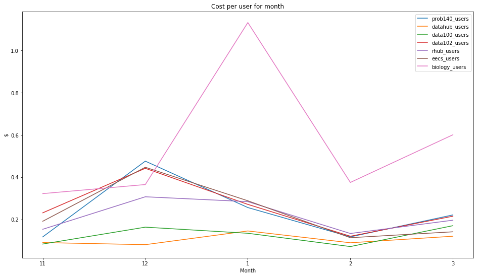

```python
plt.figure(figsize = (16,9))
for col in costs_per_user.columns:
    plt.plot([str(i) for i in costs_per_user.index], costs_per_user[col].values, label = col)
plt.legend()
plt.title("Cost per user for month")
plt.xlabel("Month")
plt.ylabel("$");
```

Biology cost per user is much higher than any other hub.

data102 and prob140 are tied closely for second

Cost per user is relatively higher on average. Will check if this increase is because each user is using more memory or if its a price increase. (i.e. checking if the change in cost per user is due to price or quantity)

```python
# RAM usage per user in MiB

usage_per_user_daily = pd.DataFrame(np.round(memory_daily_raw.iloc[:, 1:9].values/users_daily_raw.iloc[:, 1:9].values))/2**20
usage_per_user_daily.columns = users_daily_raw.iloc[:, 1:9].columns
usage_per_user_daily["date"] = users_daily_raw.date
usage_per_user_daily
```

|  | prob140_users | datahub_users | data100_users | data102_users | rhub_users | eecs_users | biology_users | daily_total | date |
| --- | --- | --- | --- | --- | --- | --- | --- | --- | --- |
| 0 | 41.616630 | 1.226871 | 5.610552 | 7.560408 | 7.535496 | 9.274515 | 34.518229 | 3.470756 | 2020-10-13 |
| 1 | 17.136259 | 1.055258 | 3.657366 | 4.584554 | 3.551547 | 3.249530 | 51.855469 | 2.434943 | 2020-10-14 |
| 2 | 18.153076 | 1.205240 | 3.124854 | 4.688537 | 4.820833 | 3.414062 | 53.049805 | 2.701988 | 2020-10-15 |
| 3 | 10.047548 | 1.296679 | 14.364509 | 6.395942 | 3.186747 | 3.224960 | 5.267227 | 2.821946 | 2020-10-16 |
| 4 | 5.951770 | 4.251122 | 50.292969 | 10.466086 | 13.443866 | 25.198438 | 41.084375 | 8.600868 | 2020-10-17 |
| ... | ... | ... | ... | ... | ... | ... | ... | ... | ... |
| 179 | 12.539062 | 3.435441 | 29.095776 | 12.851875 | 11.307556 | 44.683281 | 207.800781 | 10.800540 | 2021-04-10 |
| 180 | 8.700169 | 7.977158 | 27.774038 | 5.236443 | 12.104553 | 31.228722 | 207.800781 | 12.911019 | 2021-04-11 |
| 181 | 3.761735 | 4.758422 | 7.482682 | 12.639137 | 6.536880 | 4.467773 | 63.229167 | 5.357877 | 2021-04-12 |
| 182 | 19.439342 | 6.914478 | 10.766087 | 10.674072 | 6.426562 | 7.224489 | 38.195312 | 8.592211 | 2021-04-13 |
| 183 | 87.640300 | 7.515369 | 10.223000 | 9.179861 | 11.917010 | 5.721550 | 32.216146 | 8.892618 | 2021-04-14 |

184 rows × 9 columns

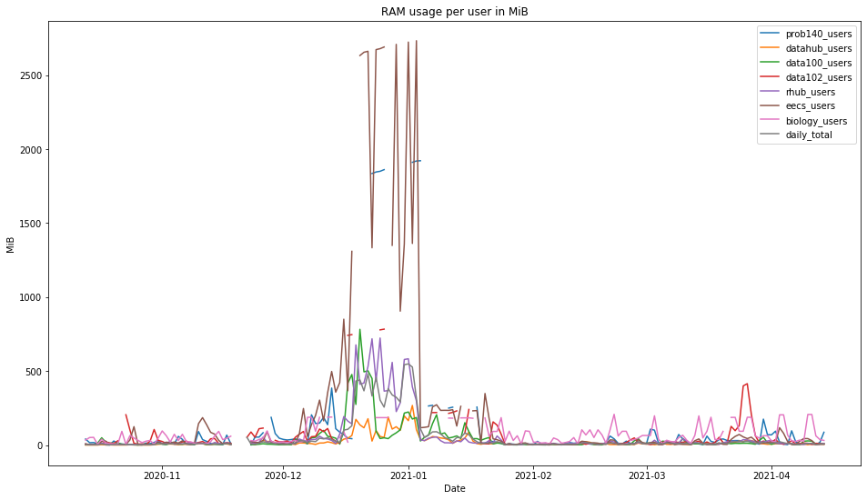

```python
plt.figure(figsize = (16,9))
for col in usage_per_user_daily.columns[:-1]:
    plt.plot(usage_per_user_daily.date, usage_per_user_daily[col].values, label = col)
plt.legend()
plt.title("RAM usage per user in MiB")
plt.xlabel("Date")
plt.ylabel("MiB");
```

Need to exclude winter break stuff

```python
usage_per_user_daily = usage_per_user_daily[(usage_per_user_daily.date
                                             <= datetime.date(year=2020,month=12,day=18)) | (
    usage_per_user_daily.date >= datetime.date(year=2021,month=1,day=18))]
```

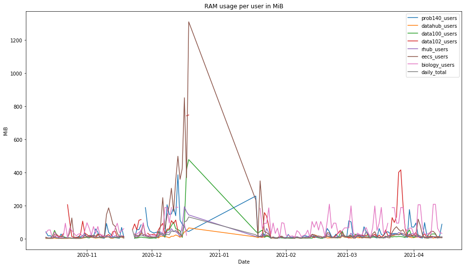

```python
plt.figure(figsize = (16,9))
for col in usage_per_user_daily.columns[:-1]:
    plt.plot(usage_per_user_daily.date, usage_per_user_daily[col].values, label = col)
plt.legend()
plt.title("RAM usage per user in MiB")
plt.xlabel("Date")
plt.ylabel("MiB");
```

still weird duirng finals week of fall 2020

```python
usage_per_user_daily = usage_per_user_daily[(usage_per_user_daily.date
                                             <= datetime.date(year=2020,month=12,day=11)) | (
    usage_per_user_daily.date >= datetime.date(year=2021,month=1,day=18))]
```

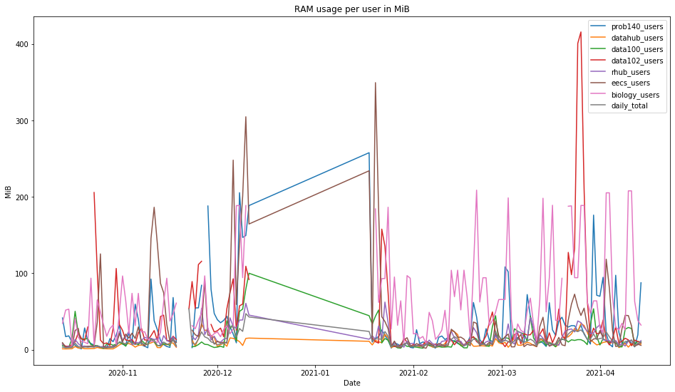

```python
plt.figure(figsize = (16,9))
for col in usage_per_user_daily.columns[:-1]:
    plt.plot(usage_per_user_daily.date, usage_per_user_daily[col].values, label = col)
plt.legend()
plt.title("RAM usage per user in MiB")
plt.xlabel("Date")
plt.ylabel("MiB");
```

we can see in above graph that biology usage per user is much higher than other hubs. followed by data102 and prob140 .

lets look at the data monthly to reduce variability

```python
usage_month = memory_daily_raw.iloc[:, 1:10].groupby("month", sort = False).sum().iloc[1:-1].drop(
    columns = "daily_total")/2**20
usage_month
```

| month | prob140_memory | datahub_memory | data100_memory | data102_memory | rhub_memory | eecs_memory | biology_memory |
| --- | --- | --- | --- | --- | --- | --- | --- |
| 11 | 16700.273438 | 62774.406250 | 33928.156250 | 8432.933594 | 16561.218750 | 13525.750000 | 5081.816406 |
| 12 | 46333.441406 | 63051.546875 | 60218.332031 | 19815.156250 | 52382.531250 | 74775.597656 | 5814.238281 |
| 1 | 20980.804688 | 41963.847656 | 22652.054688 | 12208.242188 | 26206.296875 | 20541.933594 | 5738.414062 |
| 2 | 16652.929688 | 65847.199219 | 33214.089844 | 11184.253906 | 21463.902344 | 42827.031250 | 5585.585938 |
| 3 | 22339.433594 | 73469.921875 | 45532.476562 | 14042.011719 | 27276.105469 | 39173.058594 | 6030.308594 |

In the above table, we can see that memory usage as an absolute amount has increased this semester for all hubs.

Also note the spike in usage in December.

```python
users_month
```

| month | prob140_users | datahub_users | data100_users | data102_users | rhub_users | eecs_users | biology_users |
| --- | --- | --- | --- | --- | --- | --- | --- |
| 11 | 1747.0 | 8502.0 | 5015.0 | 447.0 | 1323.0 | 868.0 | 193.0 |
| 12 | 458.0 | 3702.0 | 1740.0 | 211.0 | 803.0 | 788.0 | 75.0 |
| 1 | 1052.0 | 3703.0 | 2167.0 | 578.0 | 1183.0 | 916.0 | 65.0 |
| 2 | 1887.0 | 9802.0 | 6155.0 | 1238.0 | 2131.0 | 5034.0 | 197.0 |
| 3 | 1269.0 | 7719.0 | 3367.0 | 819.0 | 1747.0 | 3491.0 | 126.0 |

monthly usage/ monthy user = usage per user

```python
usage_per_user = pd.DataFrame(np.round(usage_month.values/users_month.values, 1))
usage_per_user.columns = users_month.columns
usage_per_user.index = users_month.index
usage_per_user
```

| month | prob140_users | datahub_users | data100_users | data102_users | rhub_users | eecs_users | biology_users |
| --- | --- | --- | --- | --- | --- | --- | --- |
| 11 | 9.6 | 7.4 | 6.8 | 18.9 | 12.5 | 15.6 | 26.3 |
| 12 | 101.2 | 17.0 | 34.6 | 93.9 | 65.2 | 94.9 | 77.5 |
| 1 | 19.9 | 11.3 | 10.5 | 21.1 | 22.2 | 22.4 | 88.3 |
| 2 | 8.8 | 6.7 | 5.4 | 9.0 | 10.1 | 8.5 | 28.4 |
| 3 | 17.6 | 9.5 | 13.5 | 17.1 | 15.6 | 11.2 | 47.9 |

In most hubs, each user is using more memory. This explains rise in costs per user.

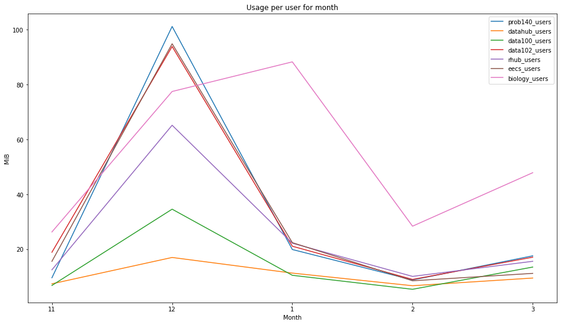

```python
plt.figure(figsize = (16,9))
for col in usage_per_user.columns:
    plt.plot([str(i) for i in usage_per_user.index], usage_per_user[col].values, label = col)
plt.legend()
plt.title("Usage per user for month")
plt.xlabel("Month")
plt.ylabel("MiB");
```

Overall, Total costs are rising quite a lot.

Some of it is explained by rising costs per user as each user uses more RAM. Will check is there are more users as well

```python
users_month
```

| month | prob140_users | datahub_users | data100_users | data102_users | rhub_users | eecs_users | biology_users |
| --- | --- | --- | --- | --- | --- | --- | --- |
| 11 | 1747.0 | 8502.0 | 5015.0 | 447.0 | 1323.0 | 868.0 | 193.0 |
| 12 | 458.0 | 3702.0 | 1740.0 | 211.0 | 803.0 | 788.0 | 75.0 |
| 1 | 1052.0 | 3703.0 | 2167.0 | 578.0 | 1183.0 | 916.0 | 65.0 |
| 2 | 1887.0 | 9802.0 | 6155.0 | 1238.0 | 2131.0 | 5034.0 | 197.0 |
| 3 | 1269.0 | 7719.0 | 3367.0 | 819.0 | 1747.0 | 3491.0 | 126.0 |

Here we can see the users have also increasing since last semester

So increase in costs is driven by by both, increased usage per user and number of users. Impact of Number is users.

EECS has singnificantly increased users.

While biology usage per user is much higher, it has fewest users.

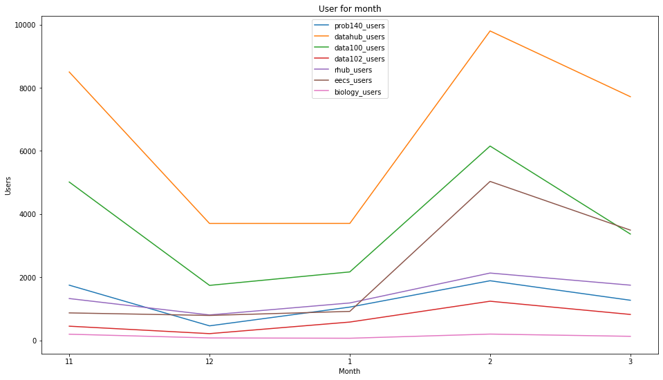

```python
plt.figure(figsize = (16,9))
for col in users_month.columns:
    plt.plot([str(i) for i in users_month.index], users_month[col].values, label = col)
plt.legend()
plt.title("User for month")
plt.xlabel("Month")
plt.ylabel("Users");
```